# aculocity

### 💡 Evaluation metrics for regression model:

- Symmetric Mean Absolute Percentage Error (SMAPE): SMAPE is a metric used to measure the accuracy of a model's forecasts. It calculates the percentage difference between the predicted and actual values while considering their average. SMAPE provides a symmetric measurement that avoids the issue of asymmetry present in other metrics like MAPE.
- Mean Absolute Error (MAE): MAE is the average of the absolute differences between the predicted and actual values. It gives an idea of how wrong the predictions were, with equal weight given to all errors.
- Mean Squared Error (MSE): MSE is similar to MAE but squares the differences before averaging them. It assigns higher weight to large errors, making it more sensitive to outliers.
- Root Mean Squared Error (RMSE): RMSE is the square root of MSE and has the same units as the original values. It is an interpretable measure that represents the standard deviation of the unexplained variance.
- R-squared (R2): R2 provides an indication of the goodness of fit of a model's predictions to the actual values. It measures the proportion of variance in the data explained by the model, with a value of 1 indicating a perfect fit.
- Mean Absolute Percentage Error (MAPE): MAPE is similar to SMAPE, but it can be asymmetrical, penalizing under- or over-forecasts differently. It depends on the distribution of the actual values and can be sensitive to extreme values.

### 💡 Popular Regression Models:

- **Linear Regression:** Linear regression models the relationship between the dependent variable and one or more independent variables by fitting a linear equation. It assumes a linear relationship between the predictors and the target variable.

  ```
  from sklearn.linear_model import LinearRegression
  ```

- **Polynomial Regression:** Polynomial regression extends linear regression by introducing polynomial terms to capture nonlinear relationships between the predictors and the target variable.

  ```
  from sklearn.preprocessing import PolynomialFeatures
    from sklearn.linear_model import LinearRegression
  ```

- **Ridge Regression:** Ridge regression is a regularized version of linear regression that adds a penalty term to the loss function. It helps to reduce overfitting and improve generalization by shrinking the coefficients towards zero.

  ```
  from sklearn.linear_model import Ridge
  ```

- **Lasso Regression:** Lasso regression, similar to ridge regression, adds a penalty term to the loss function. However, it uses L1 regularization, which can perform variable selection by setting some coefficients to exactly zero.

  ```
  from sklearn.linear_model import Lasso
  ```

- **Elastic Net Regression:** Elastic Net regression combines L1 and L2 regularization to balance the strengths of ridge and lasso regression. It can handle correlated predictors better than lasso regression alone.

  ```
  from sklearn.linear_model import ElasticNet
  ```

- **Decision Tree Regression:** Decision tree regression models the target variable by recursively partitioning the feature space into regions based on feature values. Each partition represents a leaf node with a predicted value.

  ```
  from sklearn.tree import DecisionTreeRegressor
  ```

- **Random Forest Regression:** Random forest regression is an ensemble technique that combines multiple decision trees. It improves prediction accuracy by averaging the predictions of individual trees.

  ```
  from sklearn.ensemble import RandomForestRegressor
  ```

- **Gradient Boosting Regression:** Gradient boosting regression builds an ensemble of weak prediction models, such as decision trees, in a sequential manner. Each subsequent model corrects the errors made by the previous models, leading to improved predictions.

  ```
  from sklearn.ensemble import GradientBoostingRegressor
  ```

- **Support Vector Regression (SVR):** SVR is an extension of support vector machines for regression tasks. It uses a kernel function to map the input space into a higher-dimensional feature space, allowing for nonlinear regression.

  ```
  from sklearn.svm import SVR
  ```

- **Neural Network Regression:** Neural network regression utilizes deep learning architectures to model complex relationships between predictors and the target variable. It consists of multiple interconnected layers of artificial neurons that learn to approximate the target function.

  ```
  from sklearn.neural_network import MLPRegressor
  ```

- **K-Nearest Neighbors Regression (KNN):** KNN regression predicts the target value based on the average of the target values of its k nearest neighbors in the feature space.

  ```
  from sklearn.neighbors import KNeighborsRegressor
  ```

- **Bayesian Regression:** Bayesian regression applies Bayesian inference to estimate the parameters of a regression model. It provides a probabilistic framework for incorporating prior knowledge and uncertainty in the model.

  ```
  from sklearn.linear_model import BayesianRidge
  ```

- **Gaussian Process Regression:** Gaussian process regression models the target variable as a distribution over functions. It provides a nonparametric approach to regression that captures uncertainty in predictions.

  ```
  from sklearn.gaussian_process import GaussianProcessRegressor
  ```

- **Generalized Linear Models (GLMs):** GLMs are a broad class of regression models that unify various regression techniques, including linear regression, logistic regression, and Poisson regression. They provide a flexible framework for modeling different types of data and response variables.

  ```
  from sklearn.linear_model import TweedieRegressor  # Example of GLM
  ```

- **Huber Regression:** Huber regression is a robust regression model that is less sensitive to outliers compared to ordinary least squares regression.

  ```
  from sklearn.linear_model import HuberRegressor
  ```

- **Passive Aggressive Regression:** Passive Aggressive regression is an online learning algorithm that updates its model incrementally, suitable for scenarios where data arrives in streams.

  ```
  from sklearn.linear_model import PassiveAggressiveRegressor
  ```

- **Isotonic Regression:** Isotonic regression is a nonparametric regression model that fits a monotonic function to the data.

  ```
  from sklearn.isotonic import IsotonicRegression
  ```

- **Orthogonal Matching Pursuit (OMP):** OMP is a sparse regression model that iteratively selects relevant features and fits the model using least squares.

  ```
  from sklearn.linear_model import OrthogonalMatchingPursuit
  ```

- **XGBoost Regression:** XGBoost is an optimized gradient boosting regression model known for its high performance and scalability.

  ```
  import xgboost as xgb
  ```

- **LightGBM Regression:** LightGBM is another gradient boosting regression model that offers high efficiency and handles large-scale data.

  ```
  import lightgbm as lgb
  ```

- **CatBoost Regression:** CatBoost is a gradient boosting regression model that supports categorical features and incorporates innovative techniques.

  ```
  from catboost import CatBoostRegressor
  ```

- **HistGradientBoosting Regression:** HistGradientBoosting is a histogram-based gradient boosting regression model that provides fast and accurate predictions.

  ```
  from sklearn.experimental import enable_hist_gradient_boosting
    from sklearn.ensemble import HistGradientBoostingRegressor
  ```

- **ARIMA (Autoregressive Integrated Moving Average):** ARIMA is a time series forecasting model that combines autoregressive and moving average components.

  ```
  from statsmodels.tsa.arima.model import ARIMA
  ```

- **Prophet:** Prophet is a time series forecasting model developed by Facebook that captures seasonal and trend patterns.

  ```
  from prophet import Prophet
  ```

### 🛫 Imports

```python
def ignoreWarnings():
    warnings.filterwarnings('ignore')
ignoreWarnings()
'''
--------------------------------------------------------
REGRESSION MODELS
--------------------------------------------------------
'''
from sklearn.ensemble import BaggingRegressor
from sklearn.ensemble import HistGradientBoostingRegressor
from sklearn.ensemble import RandomForestRegressor
from sklearn.linear_model import HuberRegressor
from sklearn.linear_model import PassiveAggressiveRegressor
from sklearn.linear_model import Ridge
from sklearn.linear_model import Lasso
from sklearn.linear_model import ElasticNet
from sklearn.linear_model import BayesianRidge
from sklearn.gaussian_process import GaussianProcessRegressor
from sklearn.neural_network import MLPRegressor
from sklearn.neighbors import KNeighborsRegressor
from xgboost import XGBRegressor
from lightgbm import LGBMRegressor
from catboost import CatBoostRegressor
from prophet import Prophet
'''
--------------------------------------------------------
CLASSIFICATION MODELS
--------------------------------------------------------
'''
from sklearn.ensemble import RandomForestClassifier
from sklearn.naive_bayes import MultinomialNB
from sklearn.linear_model import LogisticRegression
from sklearn import svm
from sklearn.tree import DecisionTreeClassifier
from sklearn.ensemble import GradientBoostingClassifier
from sklearn.ensemble import AdaBoostClassifier
from xgboost import XGBClassifier
from lightgbm import LGBMClassifier
from catboost import CatBoostClassifier
from sklearn.neighbors import KNeighborsClassifier
from sklearn.neural_network import MLPClassifier
from sklearn.ensemble import VotingClassifier
from sklearn.gaussian_process import GaussianProcessClassifier


'''
--------------------------------------------------------
FEAUTURE ENGINEERING
--------------------------------------------------------
'''
from nltk.stem import WordNetLemmatizer
from nltk import pos_tag
from nltk.corpus import stopwords
from nltk.corpus import wordnet
from sklearn.feature_extraction.text import CountVectorizer
from nltk.stem import PorterStemmer
from sklearn.feature_extraction.text import TfidfVectorizer
from sklearn.preprocessing import PowerTransformer
from sklearn.feature_extraction.text import TfidfVectorizer
from sklearn.base import BaseEstimator, TransformerMixin
from sklearn.metrics import plot_confusion_matrix, classification_report
from sklearn.pipeline import make_pipeline
from imblearn.over_sampling import SMOTE
from sklearn.decomposition import LatentDirichletAllocation
from sklearn.preprocessing import MinMaxScaler
from sklearn.impute import SimpleImputer
from sklearn.preprocessing import LabelEncoder, OrdinalEncoder, OneHotEncoder, StandardScaler, RobustScaler, QuantileTransformer, KBinsDiscretizer, PolynomialFeatures
from sklearn.feature_selection import SelectKBest, SelectPercentile, SelectFromModel, RFE, RFECV, VarianceThreshold
from sklearn.compose import ColumnTransformer
from sklearn.model_selection import GridSearchCV
from sklearn.decomposition import PCA, KernelPCA, NMF, TruncatedSVD, FactorAnalysis, FastICA, SparsePCA, DictionaryLearning, IncrementalPCA
'''
--------------------------------------------------------
OTHER
--------------------------------------------------------
'''
import tensorflow as tf
from tensorflow import keras
import numpy as np
import matplotlib.pyplot as plt
from sklearn.model_selection import train_test_split, cross_val_score
from sklearn.metrics import mean_squared_error, r2_score, accuracy_score, roc_auc_score
import category_encoders as ce
from sklearn.pipeline import Pipeline

import statsmodels.api as sm
from statsmodels.stats.diagnostic import het_breuschpagan

from datetime import datetime
import seaborn as sns
import plotly.express as px
import pandas as pd
from functools import partial
import catboost as cb
from DataScienceMethods import Plots, Information
from category_encoders import MEstimateEncoder, GLMMEncoder, OrdinalEncoder, CatBoostEncoder
import shap
import warnings
from sklearn.cluster import KMeans
from sklearn.discriminant_analysis import LinearDiscriminantAnalysis, QuadraticDiscriminantAnalysis
import optuna
from scipy import stats
from sklearn.metrics import mean_squared_error, mean_absolute_error, r2_score
import xgboost as xgb
```

### 📊 Exploratory Data Analysis

```python
training = pd.read_csv('Training.csv', delimiter=';')
testing = pd.read_csv('Testing.csv', delimiter=';')

#Unlock display limit
pd.set_option('display.max_columns', None)

numericColumns = ['ActualWeightFront','ActualWeightBack','ActualWeightTotal','WheelBase','Overhang']
numericColumnsNoTarget = ['WheelBase','Overhang']
targetColumns = ['ActualWeightTotal','ActualWeightFront','ActualWeightBack']

target_ActualWeightBack = training['ActualWeightBack']
target_ActualWeightFront = training['ActualWeightFront']
target_ActualWeightTotal = training['ActualWeightTotal']
```

### 📚 By the Books

Let's check to see if there are any null values

```python
#Count null values
print(training.isnull().sum())
training.head()
```

```
TruckSID              0
ActualWeightFront     0
ActualWeightBack      0
ActualWeightTotal     0
Engine                0
Transmission          0
FrontAxlePosition     0
WheelBase             0
Overhang              0
FrameRails            0
Liner                 0
FrontEndExt           0
Cab                   0
RearAxels             0
RearSusp              0
FrontSusp             0
RearWheels            0
RearTires             0
FrontWheels           0
FrontTires            0
TagAxle               0
EngineFamily          0
TransmissionFamily    0
dtype: int64
```

|  | TruckSID | ActualWeightFront | ActualWeightBack | ActualWeightTotal | Engine | Transmission | FrontAxlePosition | WheelBase | Overhang | FrameRails | Liner | FrontEndExt | Cab | RearAxels | RearSusp | FrontSusp | RearWheels | RearTires | FrontWheels | FrontTires | TagAxle | EngineFamily | TransmissionFamily |
| --- | --- | --- | --- | --- | --- | --- | --- | --- | --- | --- | --- | --- | --- | --- | --- | --- | --- | --- | --- | --- | --- | --- | --- |
| 0 | 31081 | 11280 | 8030 | 19310 | 1012011 | 2700028 | 3690005 | 249 | 104 | 403012 | 404002 | 4070004 | 5000002 | 330444 | 3500004 | 3700002 | 9140014 | 933469 | 9050015 | 930469 | 3P1998 | 101D100 | 270C25 |
| 1 | 30580 | 10720 | 6660 | 17380 | 1012011 | 2700022 | 3690005 | 183 | 68 | 403012 | 404002 | 4070004 | 5000004 | 330507 | 3500004 | 3700011 | 9142001 | 933469 | 9050031 | 930821 | 3P1998 | 101D100 | 270C24 |
| 2 | 31518 | 11040 | 6230 | 17270 | 1012001 | 2700022 | 3690005 | 216 | 68 | 403012 | 404002 | 4070004 | 5000001 | 330444 | 3500004 | 3700002 | 9140014 | 933062 | 9050015 | 930469 | 3P1998 | 101D97 | 270C24 |
| 3 | 31816 | 11210 | 7430 | 18640 | 1012002 | 2700028 | 3690005 | 219 | 104 | 403012 | 404002 | 4070004 | 5000002 | 330444 | 3500004 | 3700002 | 9140014 | 933062 | 9050015 | 930469 | 3P1998 | 101D97 | 270C25 |
| 4 | 30799 | 11910 | 7510 | 19420 | 1012019 | 2700028 | 3690005 | 231 | 104 | 403012 | 404002 | 4070004 | 5000001 | 330444 | 3500004 | 3700011 | 9142001 | 933469 | 9050037 | 930469 | 3P1998 | 101D102 | 270C25 |

```python
print(testing.isnull().sum())
testing.head()
```

```
TruckSID              0
Engine                0
Transmission          0
FrontAxlePosition     0
WheelBase             0
Overhang              0
FrameRails            0
Liner                 0
FrontEndExt           0
Cab                   0
RearAxels             0
RearSusp              0
FrontSusp             0
RearWheels            0
RearTires             0
FrontWheels           0
FrontTires            0
TagAxle               0
EngineFamily          0
TransmissionFamily    0
dtype: int64
```

|  | TruckSID | Engine | Transmission | FrontAxlePosition | WheelBase | Overhang | FrameRails | Liner | FrontEndExt | Cab | RearAxels | RearSusp | FrontSusp | RearWheels | RearTires | FrontWheels | FrontTires | TagAxle | EngineFamily | TransmissionFamily |
| --- | --- | --- | --- | --- | --- | --- | --- | --- | --- | --- | --- | --- | --- | --- | --- | --- | --- | --- | --- | --- |
| 0 | 35433 | 1012003 | 2700028 | 3690005 | 207 | 98 | 403012 | 404998 | 4070004 | 5000001 | 330444 | 3500004 | 3700002 | 9140022 | 933062 | 9050037 | 930469 | 3P1998 | 101D97 | 270C25 |
| 1 | 31091 | 1012019 | 2700028 | 3690005 | 201 | 62 | 403011 | 404002 | 4070004 | 5000004 | 330507 | 3500004 | 3700011 | 9142001 | 933469 | 9050037 | 930469 | 3P1998 | 101D102 | 270C25 |
| 2 | 26771 | 1012002 | 2700022 | 3690005 | 213 | 62 | 403011 | 404002 | 4070004 | 5000001 | 330444 | 3500004 | 3700002 | 9142001 | 933469 | 9050031 | 930821 | 3P1998 | 101D97 | 270C24 |
| 3 | 29201 | 1012003 | 2700022 | 3690005 | 192 | 110 | 403012 | 404998 | 4070004 | 5000001 | 3300041 | 3500014 | 3700002 | 9140005 | 933062 | 905549 | 930821 | 3P1998 | 101D97 | 270C24 |
| 4 | 31083 | 1012011 | 2700028 | 3690005 | 249 | 104 | 403012 | 404002 | 4070004 | 5000002 | 330444 | 3500004 | 3700002 | 9140014 | 933469 | 9050015 | 930469 | 3P1998 | 101D100 | 270C25 |

### 💡 Findings

```python
print(f'''
      The shape of the training dataset is: {training.shape}
      The shape of the testing dataset is: {testing.shape}

      The training dataset is missing the following columns:

        {set( training.columns ) - set( testing.columns )}

      ''')
```

```
      The shape of the training dataset is: (2644, 23)
      The shape of the testing dataset is: (962, 20)

      The training dataset is missing the following columns:

        {'ActualWeightBack', 'ActualWeightFront', 'ActualWeightTotal'}
```

### 💡 Findings

This is a very small dataset so we can rule out deep learning.

```python
training.info()
```

```
<class 'pandas.core.frame.DataFrame'>
RangeIndex: 2644 entries, 0 to 2643
Data columns (total 23 columns):
 #   Column              Non-Null Count  Dtype
---  ------              --------------  -----
 0   TruckSID            2644 non-null   int64
 1   ActualWeightFront   2644 non-null   int64
 2   ActualWeightBack    2644 non-null   int64
 3   ActualWeightTotal   2644 non-null   int64
 4   Engine              2644 non-null   int64
 5   Transmission        2644 non-null   int64
 6   FrontAxlePosition   2644 non-null   int64
 7   WheelBase           2644 non-null   int64
 8   Overhang            2644 non-null   int64
 9   FrameRails          2644 non-null   int64
 10  Liner               2644 non-null   int64
 11  FrontEndExt         2644 non-null   int64
 12  Cab                 2644 non-null   int64
 13  RearAxels           2644 non-null   int64
 14  RearSusp            2644 non-null   int64
 15  FrontSusp           2644 non-null   int64
 16  RearWheels          2644 non-null   int64
 17  RearTires           2644 non-null   int64
 18  FrontWheels         2644 non-null   int64
 19  FrontTires          2644 non-null   int64
 20  TagAxle             2644 non-null   object
 21  EngineFamily        2644 non-null   object
 22  TransmissionFamily  2644 non-null   object
dtypes: int64(20), object(3)
memory usage: 475.2+ KB
```

```python
testing.info()
```

```
<class 'pandas.core.frame.DataFrame'>
RangeIndex: 962 entries, 0 to 961
Data columns (total 20 columns):
 #   Column              Non-Null Count  Dtype
---  ------              --------------  -----
 0   TruckSID            962 non-null    int64
 1   Engine              962 non-null    int64
 2   Transmission        962 non-null    int64
 3   FrontAxlePosition   962 non-null    int64
 4   WheelBase           962 non-null    int64
 5   Overhang            962 non-null    int64
 6   FrameRails          962 non-null    int64
 7   Liner               962 non-null    int64
 8   FrontEndExt         962 non-null    int64
 9   Cab                 962 non-null    object
 10  RearAxels           962 non-null    int64
 11  RearSusp            962 non-null    int64
 12  FrontSusp           962 non-null    object
 13  RearWheels          962 non-null    int64
 14  RearTires           962 non-null    int64
 15  FrontWheels         962 non-null    int64
 16  FrontTires          962 non-null    int64
 17  TagAxle             962 non-null    object
 18  EngineFamily        962 non-null    object
 19  TransmissionFamily  962 non-null    object
dtypes: int64(15), object(5)
memory usage: 150.4+ KB
```

```python
'''
Take only the numeric columns for analysis
'''
training_numeric = training[numericColumns]
testing_numeric = testing[numericColumnsNoTarget]
training_numeric
```

|  | ActualWeightFront | ActualWeightBack | ActualWeightTotal | WheelBase | Overhang |
| --- | --- | --- | --- | --- | --- |
| 0 | 11280 | 8030 | 19310 | 249 | 104 |
| 1 | 10720 | 6660 | 17380 | 183 | 68 |
| 2 | 11040 | 6230 | 17270 | 216 | 68 |
| 3 | 11210 | 7430 | 18640 | 219 | 104 |
| 4 | 11910 | 7510 | 19420 | 231 | 104 |
| ... | ... | ... | ... | ... | ... |
| 2639 | 10110 | 9830 | 19940 | 210 | 104 |
| 2640 | 11150 | 6700 | 17850 | 210 | 74 |
| 2641 | 10850 | 7020 | 17870 | 222 | 80 |
| 2642 | 10380 | 6850 | 17230 | 222 | 56 |
| 2643 | 9820 | 8760 | 18580 | 198 | 104 |

2644 rows × 5 columns

```python
training.nunique()
```

```
TruckSID              2640
ActualWeightFront      350
ActualWeightBack       441
ActualWeightTotal      520
Engine                  12
Transmission             5
FrontAxlePosition        2
WheelBase               35
Overhang                13
FrameRails               3
Liner                    3
FrontEndExt              2
Cab                      5
RearAxels                4
RearSusp                 4
FrontSusp                4
RearWheels              10
RearTires                5
FrontWheels             11
FrontTires               4
TagAxle                  9
EngineFamily             9
TransmissionFamily       4
dtype: int64
```

### 💡 Findings

There seem to be a lot of categorical columns which are considered ints

ISSUES:

The model will assume an order to these even though they are not ordinal.  
It will be important to somehow deal when this without going crazy with dummy values.  
Although some tree-based and gradient-boosted tree-based models can handle high dimensionality others cannot.

```python
dataframeWithoutTarget = training.drop(columns=targetColumns)
#Get all the object columns
obj_cols_ = [col for col in training.columns if col not in numericColumns]
training[obj_cols_] = training[obj_cols_].astype('string')
testing[obj_cols_] = testing[obj_cols_].astype('string')
training.info()
```

```
<class 'pandas.core.frame.DataFrame'>
RangeIndex: 2644 entries, 0 to 2643
Data columns (total 23 columns):
 #   Column              Non-Null Count  Dtype
---  ------              --------------  -----
 0   TruckSID            2644 non-null   string
 1   ActualWeightFront   2644 non-null   int64
 2   ActualWeightBack    2644 non-null   int64
 3   ActualWeightTotal   2644 non-null   int64
 4   Engine              2644 non-null   string
 5   Transmission        2644 non-null   string
 6   FrontAxlePosition   2644 non-null   string
 7   WheelBase           2644 non-null   int64
 8   Overhang            2644 non-null   int64
 9   FrameRails          2644 non-null   string
 10  Liner               2644 non-null   string
 11  FrontEndExt         2644 non-null   string
 12  Cab                 2644 non-null   string
 13  RearAxels           2644 non-null   string
 14  RearSusp            2644 non-null   string
 15  FrontSusp           2644 non-null   string
 16  RearWheels          2644 non-null   string
 17  RearTires           2644 non-null   string
 18  FrontWheels         2644 non-null   string
 19  FrontTires          2644 non-null   string
 20  TagAxle             2644 non-null   string
 21  EngineFamily        2644 non-null   string
 22  TransmissionFamily  2644 non-null   string
dtypes: int64(5), string(18)
memory usage: 475.2 KB
```

### 💡 Findings

Cab and FrontSusp are objects in the testing data but ints in the training data.  
This implies that the testing data might be dirty or hold values that do not exist in the training data.

```python
cols_in_training = training.columns.to_list()
#Exclude the TruckSID column
cols_in_testing = testing.columns.to_list()[1:]

#Get all the columns that are not numeric
cols_in_training = [item for item in cols_in_training if item not in numericColumns]
cols_in_testing = [item for item in cols_in_testing if item not in numericColumns]


for col in cols_in_testing:
    training_values = set(training[col].unique())
    testing_values = set(testing[col].unique())

    # Find values in testing that are not in training
    diff_values = testing_values - training_values

    # Print out the different values
    for val in diff_values:
        print(f"'{val}' from '{col}' is not in the training set")
```

```
'2700023' from 'Transmission' is not in the training set
'500QXX' from 'Cab' is not in the training set
'330545' from 'RearAxels' is not in the training set
'370QXX' from 'FrontSusp' is not in the training set
'914105' from 'RearWheels' is not in the training set
'9140019' from 'RearWheels' is not in the training set
```

### 💡 Findings

There appear to be some new categories which look very suspicious. Some might be new but others are probably misspellings.  
When we encode the category variables I will use

TargetEncoder(handle_unknown='value', handle_missing='value')

This will ensure that when new values it does not recognise are added it will convert them to -1 or the average

```python
training['EngineFamily'].unique()
```

```
<StringArray>
[ '101D100',   '101D97',  '101D102',  '101D97 ',  '101D97.',   '101D56',
   '101D69', '101.D100',   '101D67']
Length: 9, dtype: string
```

### 💡 Findings

There seem to be some '.' in the data, these appear to be mistakes so we will quickly get rid of them.

```python
all_cols = training.columns
for col in all_cols:
    try:
        training[col] = training[col].str.replace(' ', '')
    except:
        pass

training['EngineFamily'] = training['EngineFamily'].str.replace('.', '')
training['EngineFamily'].unique()
```

```
<StringArray>
['101D100', '101D97', '101D102', '101D56', '101D69', '101D67']
Length: 6, dtype: string
```

### 💡 Findings

All anomalies have been dealt with.  
Let's continue looking at the data

```python
from DataScienceMethods import Information, Plots
Information.summary(training_numeric)
```

```
data shape: (2644, 5)
```

|  | data type | #missing | %missing | #unique | min | max | first value | second value | third value |
| --- | --- | --- | --- | --- | --- | --- | --- | --- | --- |
| ActualWeightFront | int64 | 0 | 0.0 | 350 | 7801.0 | 12890.0 | 11280 | 10720 | 11040 |
| ActualWeightBack | int64 | 0 | 0.0 | 441 | 4650.0 | 10030.0 | 8030 | 6660 | 6230 |
| ActualWeightTotal | int64 | 0 | 0.0 | 520 | 15721.0 | 20640.0 | 19310 | 17380 | 17270 |
| WheelBase | int64 | 0 | 0.0 | 35 | 162.0 | 285.0 | 249 | 183 | 216 |
| Overhang | int64 | 0 | 0.0 | 13 | 56.0 | 3618545.0 | 104 | 68 | 68 |

### 💡 Findings

3 million seems a bit excessive for an overhang

It is obviously an outlier so let's see if the testing data shares the same fate.

```python
Information.summary(testing_numeric)
```

```
data shape: (962, 2)
```

|  | data type | #missing | %missing | #unique | min | max | first value | second value | third value |
| --- | --- | --- | --- | --- | --- | --- | --- | --- | --- |
| WheelBase | int64 | 0 | 0.0 | 42 | 150.0 | 285.0 | 207 | 201 | 213 |
| Overhang | int64 | 0 | 0.0 | 14 | 56.0 | 3618545.0 | 98 | 62 | 62 |

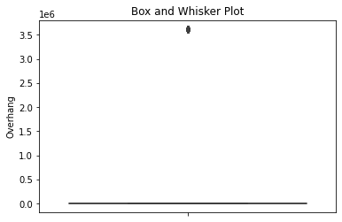

```python
sns.boxplot(y=training_numeric['Overhang'])
plt.title('Box and Whisker Plot')
plt.show()
```

### 💡 Findings

The testing data also has the large outlier.  
This means this might be a common occurence in the data.  
So instead of dropping these outliers, let's rather convert them to the average (That is present without the outliers) which is 90

```python
'''
Replace all outliers with a given value (90)
'''
def replaceOutliers(data, variable, multiplier=1.5, replacement_value=90):
    Q1 = data[variable].quantile(0.25) #Specify the first quartile
    Q3 = data[variable].quantile(0.75) #Specify the third quartile
    IQR = Q3 - Q1 #Interquartile range

    lower_bound = Q1 - multiplier*IQR #Specify the lower bound
    upper_bound = Q3 + multiplier*IQR #Specify the upper bound
    print('Lower bound: ', lower_bound)
    print('Upper bound: ', upper_bound)
    # Replacing outliers with the given value
    data.loc[data[variable] < lower_bound, variable] = replacement_value
    data.loc[data[variable] > upper_bound, variable] = replacement_value
    return data

training_numeric = replaceOutliers(training_numeric, 'Overhang', 10)
Information.summary(training_numeric)
```

```
Lower bound:  -160.0
Upper bound:  344.0
data shape: (2644, 5)
```

|  | data type | #missing | %missing | #unique | min | max | first value | second value | third value |
| --- | --- | --- | --- | --- | --- | --- | --- | --- | --- |
| ActualWeightFront | int64 | 0 | 0.0 | 350 | 7801.0 | 12890.0 | 11280 | 10720 | 11040 |
| ActualWeightBack | int64 | 0 | 0.0 | 441 | 4650.0 | 10030.0 | 8030 | 6660 | 6230 |
| ActualWeightTotal | int64 | 0 | 0.0 | 520 | 15721.0 | 20640.0 | 19310 | 17380 | 17270 |
| WheelBase | int64 | 0 | 0.0 | 35 | 162.0 | 285.0 | 249 | 183 | 216 |
| Overhang | int64 | 0 | 0.0 | 12 | 56.0 | 128.0 | 104 | 68 | 68 |

```python
training = replaceOutliers(training,'Overhang', 10)
testing = replaceOutliers(testing,'Overhang', 10)
Information.summary(training)
```

```
Lower bound:  -160.0
Upper bound:  344.0
Lower bound:  -160.0
Upper bound:  344.0
data shape: (2644, 23)
```

|  | data type | #missing | %missing | #unique | min | max | first value | second value | third value |
| --- | --- | --- | --- | --- | --- | --- | --- | --- | --- |
| TruckSID | string | 0 | 0.0 | 2640 | NaN | NaN | 31081 | 30580 | 31518 |
| ActualWeightFront | int64 | 0 | 0.0 | 350 | 7801.0 | 12890.0 | 11280 | 10720 | 11040 |
| ActualWeightBack | int64 | 0 | 0.0 | 441 | 4650.0 | 10030.0 | 8030 | 6660 | 6230 |
| ActualWeightTotal | int64 | 0 | 0.0 | 520 | 15721.0 | 20640.0 | 19310 | 17380 | 17270 |
| Engine | string | 0 | 0.0 | 12 | NaN | NaN | 1012011 | 1012011 | 1012001 |
| Transmission | string | 0 | 0.0 | 5 | NaN | NaN | 2700028 | 2700022 | 2700022 |
| FrontAxlePosition | string | 0 | 0.0 | 2 | NaN | NaN | 3690005 | 3690005 | 3690005 |
| WheelBase | int64 | 0 | 0.0 | 35 | 162.0 | 285.0 | 249 | 183 | 216 |
| Overhang | int64 | 0 | 0.0 | 12 | 56.0 | 128.0 | 104 | 68 | 68 |
| FrameRails | string | 0 | 0.0 | 3 | NaN | NaN | 403012 | 403012 | 403012 |
| Liner | string | 0 | 0.0 | 3 | NaN | NaN | 404002 | 404002 | 404002 |
| FrontEndExt | string | 0 | 0.0 | 2 | NaN | NaN | 4070004 | 4070004 | 4070004 |
| Cab | string | 0 | 0.0 | 5 | NaN | NaN | 5000002 | 5000004 | 5000001 |
| RearAxels | string | 0 | 0.0 | 4 | NaN | NaN | 330444 | 330507 | 330444 |
| RearSusp | string | 0 | 0.0 | 4 | NaN | NaN | 3500004 | 3500004 | 3500004 |
| FrontSusp | string | 0 | 0.0 | 4 | NaN | NaN | 3700002 | 3700011 | 3700002 |
| RearWheels | string | 0 | 0.0 | 10 | NaN | NaN | 9140014 | 9142001 | 9140014 |
| RearTires | string | 0 | 0.0 | 5 | NaN | NaN | 933469 | 933469 | 933062 |
| FrontWheels | string | 0 | 0.0 | 11 | NaN | NaN | 9050015 | 9050031 | 9050015 |
| FrontTires | string | 0 | 0.0 | 4 | NaN | NaN | 930469 | 930821 | 930469 |
| TagAxle | string | 0 | 0.0 | 7 | NaN | NaN | 3P1998 | 3P1998 | 3P1998 |
| EngineFamily | string | 0 | 0.0 | 6 | NaN | NaN | 101D100 | 101D100 | 101D97 |
| TransmissionFamily | string | 0 | 0.0 | 2 | NaN | NaN | 270C25 | 270C24 | 270C24 |

```python
Information.summary(testing)
```

```
data shape: (962, 20)
```

|  | data type | #missing | %missing | #unique | min | max | first value | second value | third value |
| --- | --- | --- | --- | --- | --- | --- | --- | --- | --- |
| TruckSID | string | 0 | 0.0 | 962 | NaN | NaN | 35433 | 31091 | 26771 |
| Engine | string | 0 | 0.0 | 12 | NaN | NaN | 1012003 | 1012019 | 1012002 |
| Transmission | string | 0 | 0.0 | 6 | NaN | NaN | 2700028 | 2700028 | 2700022 |
| FrontAxlePosition | string | 0 | 0.0 | 2 | NaN | NaN | 3690005 | 3690005 | 3690005 |
| WheelBase | int64 | 0 | 0.0 | 42 | 150.0 | 285.0 | 207 | 201 | 213 |
| Overhang | int64 | 0 | 0.0 | 13 | 56.0 | 128.0 | 98 | 62 | 62 |
| FrameRails | string | 0 | 0.0 | 3 | NaN | NaN | 403012 | 403011 | 403011 |
| Liner | string | 0 | 0.0 | 3 | NaN | NaN | 404998 | 404002 | 404002 |
| FrontEndExt | string | 0 | 0.0 | 2 | NaN | NaN | 4070004 | 4070004 | 4070004 |
| Cab | string | 0 | 0.0 | 6 | NaN | NaN | 5000001 | 5000004 | 5000001 |
| RearAxels | string | 0 | 0.0 | 5 | NaN | NaN | 330444 | 330507 | 330444 |
| RearSusp | string | 0 | 0.0 | 4 | NaN | NaN | 3500004 | 3500004 | 3500004 |
| FrontSusp | string | 0 | 0.0 | 5 | NaN | NaN | 3700002 | 3700011 | 3700002 |
| RearWheels | string | 0 | 0.0 | 12 | NaN | NaN | 9140022 | 9142001 | 9142001 |
| RearTires | string | 0 | 0.0 | 5 | NaN | NaN | 933062 | 933469 | 933469 |
| FrontWheels | string | 0 | 0.0 | 11 | NaN | NaN | 9050037 | 9050037 | 9050031 |
| FrontTires | string | 0 | 0.0 | 4 | NaN | NaN | 930469 | 930469 | 930821 |
| TagAxle | string | 0 | 0.0 | 6 | NaN | NaN | 3P1998 | 3P1998 | 3P1998 |
| EngineFamily | string | 0 | 0.0 | 6 | NaN | NaN | 101D97 | 101D102 | 101D97 |
| TransmissionFamily | string | 0 | 0.0 | 2 | NaN | NaN | 270C25 | 270C25 | 270C24 |

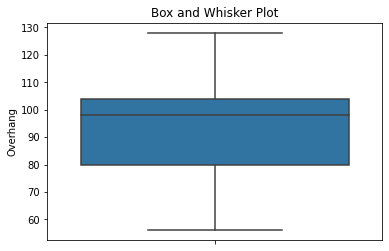

```python
sns.boxplot(y=training_numeric['Overhang'])
plt.title('Box and Whisker Plot')
plt.show()
```

### 💡 Findings

```python
training.info()
```

```
<class 'pandas.core.frame.DataFrame'>
RangeIndex: 2644 entries, 0 to 2643
Data columns (total 23 columns):
 #   Column              Non-Null Count  Dtype
---  ------              --------------  -----
 0   TruckSID            2644 non-null   string
 1   ActualWeightFront   2644 non-null   int64
 2   ActualWeightBack    2644 non-null   int64
 3   ActualWeightTotal   2644 non-null   int64
 4   Engine              2644 non-null   string
 5   Transmission        2644 non-null   string
 6   FrontAxlePosition   2644 non-null   string
 7   WheelBase           2644 non-null   int64
 8   Overhang            2644 non-null   int64
 9   FrameRails          2644 non-null   string
 10  Liner               2644 non-null   string
 11  FrontEndExt         2644 non-null   string
 12  Cab                 2644 non-null   string
 13  RearAxels           2644 non-null   string
 14  RearSusp            2644 non-null   string
 15  FrontSusp           2644 non-null   string
 16  RearWheels          2644 non-null   string
 17  RearTires           2644 non-null   string
 18  FrontWheels         2644 non-null   string
 19  FrontTires          2644 non-null   string
 20  TagAxle             2644 non-null   string
 21  EngineFamily        2644 non-null   string
 22  TransmissionFamily  2644 non-null   string
dtypes: int64(5), string(18)
memory usage: 475.2 KB
```

```python
training.to_csv('training_super_clean2.csv', index=False)
```

### 📚 By the Books

Let's check the correlations between the numeric features and the target variables.

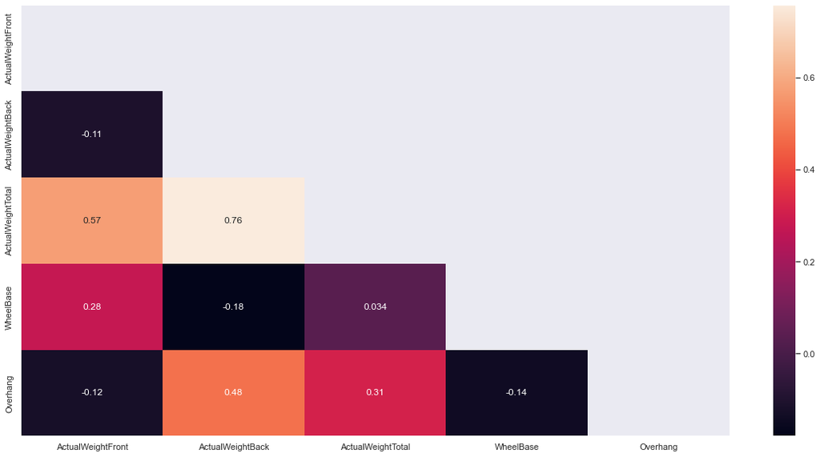

```python
# Create a mask for the upper triangle.
mask = np.triu(np.ones_like(training_numeric.corr(), dtype=bool))
# Set up the matplotlib figure size.
sns.set(rc={'figure.figsize':(20,10)})
# Draw the heatmap with the mask.
sns.heatmap(training_numeric.corr(), annot=True, mask=mask)
```

### 💡 Findings

We see a slight positive correlation between Back and total from overhang, but no variables stand out as heroes.

### 🧠 A good idea

Let's check for Heteroskedasticity

```python
def checkForHeteroskedasticity(dependentNames,dependentVariables,independentNames,independentVariables):
    for y_name, y in zip(dependentNames, dependentVariables):
        for X_name, X in zip(independentNames, independentVariables):
            X = sm.add_constant(X)
            print(f'{y_name} - {X_name}')
            # Fit regression model
            model = sm.OLS(y, X).fit()

            # Perform Breusch-Pagan test
            bp_test = het_breuschpagan(model.resid, model.model.exog)
            labels = ['LM Statistic', 'LM-Test p-value', 'F-Statistic', 'F-Test p-value']
            results = dict(zip(labels, bp_test))

            print(results)

            alpha = 0.05
            if results['LM-Test p-value'] < alpha or results['F-Test p-value'] < alpha:
                print("Reject the null hypothesis: Evidence of heteroskedasticity.")
            else:
                print("Fail to reject the null hypothesis: No evidence of heteroskedasticity.")
            print('')

target_ActualWeightTotal = training_numeric['ActualWeightTotal']
target_ActualWeightFront = training_numeric['ActualWeightFront']
target_ActualWeightBack = training_numeric['ActualWeightBack']
X_WheelBase = training_numeric['WheelBase']
X_Overhang = training_numeric['Overhang']
X_All = training_numeric.drop(['ActualWeightTotal', 'ActualWeightFront', 'ActualWeightBack'], axis=1)

dependentVariables = [target_ActualWeightTotal, target_ActualWeightFront, target_ActualWeightBack]
independentVariables = [X_WheelBase, X_Overhang, X_All]

dependentNames = ['ActualWeightTotal', 'ActualWeightFront', 'ActualWeightBack']
independentNames = ['WheelBase', 'Overhang', 'All']

checkForHeteroskedasticity(dependentNames,dependentVariables,independentNames,independentVariables)
```

```
ActualWeightTotal - WheelBase
{'LM Statistic': 8.762936123953516, 'LM-Test p-value': 0.003074137501122203, 'F-Statistic': 8.785424870061815, 'F-Test p-value': 0.0030636132978057976}
Reject the null hypothesis: Evidence of heteroskedasticity.

ActualWeightTotal - Overhang
{'LM Statistic': 3.6970266508277803, 'LM-Test p-value': 0.054509523567570786, 'F-Statistic': 3.6994028753816743, 'F-Test p-value': 0.054539291785276965}
Fail to reject the null hypothesis: No evidence of heteroskedasticity.

ActualWeightTotal - All
{'LM Statistic': 11.745150415183469, 'LM-Test p-value': 0.0028156132013616875, 'F-Statistic': 5.892085686800411, 'F-Test p-value': 0.0027976391354201393}
Reject the null hypothesis: Evidence of heteroskedasticity.

ActualWeightFront - WheelBase
{'LM Statistic': 32.94340347638752, 'LM-Test p-value': 9.488113756834247e-09, 'F-Statistic': 33.333812871194404, 'F-Test p-value': 8.668664400292033e-09}
Reject the null hypothesis: Evidence of heteroskedasticity.

ActualWeightFront - Overhang
{'LM Statistic': 54.98825995311089, 'LM-Test p-value': 1.21251928235889e-13, 'F-Statistic': 56.11368251017964, 'F-Test p-value': 9.27204061053086e-14}
Reject the null hypothesis: Evidence of heteroskedasticity.

ActualWeightFront - All
{'LM Statistic': 49.82460261088168, 'LM-Test p-value': 1.516090098971871e-11, 'F-Statistic': 25.361965815374816, 'F-Test p-value': 1.2299224575118543e-11}
Reject the null hypothesis: Evidence of heteroskedasticity.

ActualWeightBack - WheelBase
{'LM Statistic': 68.88135782553877, 'LM-Test p-value': 1.0456862398888746e-16, 'F-Statistic': 70.67035452059922, 'F-Test p-value': 6.805439212303132e-17}
Reject the null hypothesis: Evidence of heteroskedasticity.

ActualWeightBack - Overhang
{'LM Statistic': 140.58584127260607, 'LM-Test p-value': 1.9820090908421064e-32, 'F-Statistic': 148.36849561921454, 'F-Test p-value': 3.0167609854688856e-33}
Reject the null hypothesis: Evidence of heteroskedasticity.

ActualWeightBack - All
{'LM Statistic': 134.89977627214296, 'LM-Test p-value': 5.091969310887176e-30, 'F-Statistic': 70.9956313752597, 'F-Test p-value': 9.274388741601217e-31}
Reject the null hypothesis: Evidence of heteroskedasticity.
```

### 💡 Findings

**ActualWeightTotal - Overhang:**  
No evidence of heteroskedasticity. Both p-values are greater than 0.05, so we fail to reject the null hypothesis.

**The Rest**  
Evidence of heteroskedasticity

When using "Overhang" to predict "ActualWeightTotal", the model's errors seem to have a constant variance, which is a good thing. It means the model is probably well-specified for this relationship, at least in terms of the assumption of homoskedasticity (constant variance of errors).

However, when "Overhang" is used to predict either "ActualWeightFront" or "ActualWeightBack", there is evidence that the variance of the model's errors is not constant. This can be problematic as it can lead to unreliable significance tests and confidence intervals.

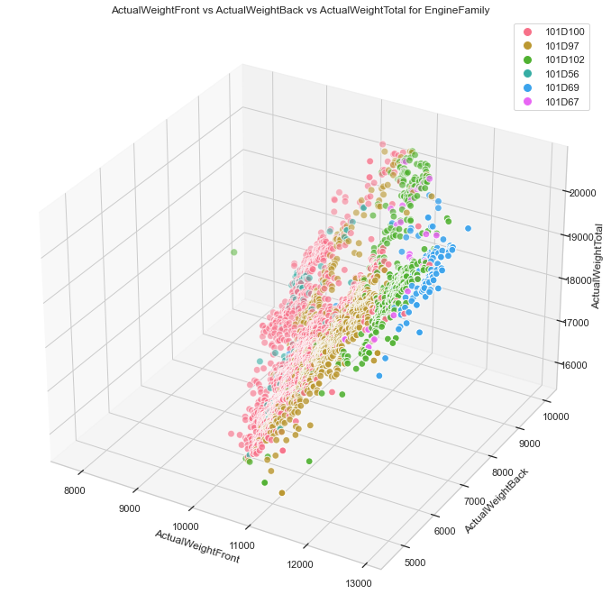

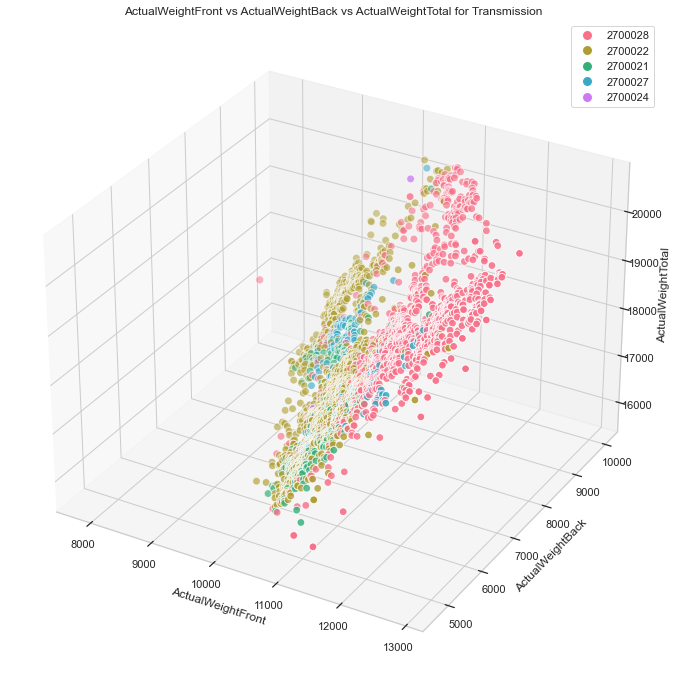

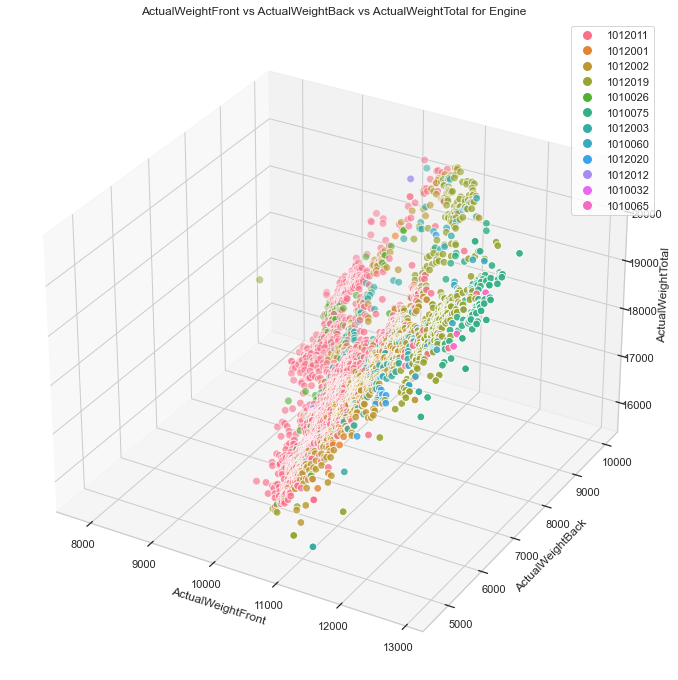

```python
def threeDScatter(df, category,X,Y,Z):
    # Create a color palette from Seaborn

    unique_categories = df[category].unique()
    palette = dict(zip(unique_categories, sns.color_palette("husl", len(unique_categories))))
    colors = df[category].map(palette)

    # Set the Seaborn style
    sns.set_style("whitegrid")

    fig = plt.figure(figsize=(12, 12))
    ax = fig.add_subplot(111, projection='3d')
    scatter = ax.scatter(df[X], df[Y], df[Z], c=colors, s=60, edgecolors='w', depthshade=True)

    # Setting the labels for the axes
    ax.set_title(f'{X} vs {Y} vs {Z} for {category}')
    ax.set_xlabel(X)
    ax.set_ylabel(Y)
    ax.set_zlabel(Z)

    # Add legend
    from matplotlib.lines import Line2D
    legend_elements = [Line2D([0], [0], marker='o', color='w', markerfacecolor=palette[key], markersize=10, label=key) for key in palette]
    ax.legend(handles=legend_elements, loc='upper right')

    plt.show()

threeDScatter(training,'EngineFamily','ActualWeightFront','ActualWeightBack','ActualWeightTotal')
threeDScatter(training,'Transmission','ActualWeightFront','ActualWeightBack','ActualWeightTotal')
threeDScatter(training,'Engine','ActualWeightFront','ActualWeightBack','ActualWeightTotal')
```

### 💡 Findings

All three features seem to show decent grouping within the data.

### 📚 By the Book

Let's define our X and y value

```python
X = training.drop(columns= targetColumns  + ['TruckSID'])
y = target_ActualWeightFront
X
```

|  | Engine | Transmission | FrontAxlePosition | WheelBase | Overhang | FrameRails | Liner | FrontEndExt | Cab | RearAxels | RearSusp | FrontSusp | RearWheels | RearTires | FrontWheels | FrontTires | TagAxle | EngineFamily | TransmissionFamily |
| --- | --- | --- | --- | --- | --- | --- | --- | --- | --- | --- | --- | --- | --- | --- | --- | --- | --- | --- | --- |
| 0 | 1012011 | 2700028 | 3690005 | 249 | 104 | 403012 | 404002 | 4070004 | 5000002 | 330444 | 3500004 | 3700002 | 9140014 | 933469 | 9050015 | 930469 | 3P1998 | 101D100 | 270C25 |
| 1 | 1012011 | 2700022 | 3690005 | 183 | 68 | 403012 | 404002 | 4070004 | 5000004 | 330507 | 3500004 | 3700011 | 9142001 | 933469 | 9050031 | 930821 | 3P1998 | 101D100 | 270C24 |
| 2 | 1012001 | 2700022 | 3690005 | 216 | 68 | 403012 | 404002 | 4070004 | 5000001 | 330444 | 3500004 | 3700002 | 9140014 | 933062 | 9050015 | 930469 | 3P1998 | 101D97 | 270C24 |
| 3 | 1012002 | 2700028 | 3690005 | 219 | 104 | 403012 | 404002 | 4070004 | 5000002 | 330444 | 3500004 | 3700002 | 9140014 | 933062 | 9050015 | 930469 | 3P1998 | 101D97 | 270C25 |
| 4 | 1012019 | 2700028 | 3690005 | 231 | 104 | 403012 | 404002 | 4070004 | 5000001 | 330444 | 3500004 | 3700011 | 9142001 | 933469 | 9050037 | 930469 | 3P1998 | 101D102 | 270C25 |
| ... | ... | ... | ... | ... | ... | ... | ... | ... | ... | ... | ... | ... | ... | ... | ... | ... | ... | ... | ... |
| 2639 | 1012012 | 2700024 | 3690005 | 210 | 104 | 403012 | 404998 | 4070004 | 5000002 | 3300041 | 3500003 | 3700002 | 9140016 | 933469 | 9050015 | 930469 | 3P1998 | 101D100 | 270C24 |
| 2640 | 1012002 | 2700028 | 3690005 | 210 | 74 | 403012 | 404002 | 4070004 | 5000003 | 330444 | 3500004 | 3700002 | 9140014 | 933062 | 9050015 | 930469 | 3P1998 | 101D97 | 270C25 |
| 2641 | 1012002 | 2700028 | 3690005 | 222 | 80 | 403012 | 404998 | 4070004 | 5000002 | 330444 | 3500014 | 3700002 | 9140014 | 933062 | 9050015 | 930469 | 3P1998 | 101D97 | 270C25 |
| 2642 | 1012011 | 2700022 | 3690005 | 222 | 56 | 403012 | 404002 | 4070004 | 5000001 | 330444 | 3500004 | 3700002 | 9142003 | 933469 | 9052003 | 930469 | 3P1998 | 101D100 | 270C24 |
| 2643 | 1012011 | 2700022 | 3690005 | 198 | 104 | 403012 | 404998 | 4070004 | 5000002 | 330507 | 3500004 | 3700002 | 9142001 | 933469 | 9050037 | 930469 | 3P1998 | 101D100 | 270C24 |

2644 rows × 19 columns

### 📚 By the Book

Let's define a pipeline to process the data

```python
# Custom transformer to convert string columns to category
class StringToCategory(BaseEstimator, TransformerMixin):
    def fit(self, X, y=None):
        return self

    def transform(self, X):
        string_cols = X.select_dtypes(include=['string']).columns
        X[string_cols] = X[string_cols].astype('category')
        return X

#Scale the data
class DataFrameScaler(BaseEstimator, TransformerMixin):
    def __init__(self):
        self.scaler = StandardScaler()
        self.columns = None

    def fit(self, X, y=None):
        self.scaler.fit(X, y)
        self.columns = X.columns
        return self

    def transform(self, X):
        X_scaled = self.scaler.transform(X)
        return pd.DataFrame(X_scaled, columns=self.columns)

# Create the pipeline
data_prep_pipeline = Pipeline([
    ('str_to_cat', StringToCategory()),
    ('target_encode', ce.TargetEncoder()),
    ('scale', DataFrameScaler())
])
```

```python
X_transformed = data_prep_pipeline.fit_transform(X, y)
X_transformed
```

|  | Engine | Transmission | FrontAxlePosition | WheelBase | Overhang | FrameRails | Liner | FrontEndExt | Cab | RearAxels | RearSusp | FrontSusp | RearWheels | RearTires | FrontWheels | FrontTires | TagAxle | EngineFamily | TransmissionFamily |
| --- | --- | --- | --- | --- | --- | --- | --- | --- | --- | --- | --- | --- | --- | --- | --- | --- | --- | --- | --- |
| 0 | -0.775150 | 1.199613 | 0.085077 | 2.620206 | 0.867729 | 0.647233 | 1.118745 | -0.061616 | -0.946623 | 0.928864 | 0.251651 | 0.402826 | 1.262227 | -0.240839 | 1.224191 | -0.359090 | -0.15539 | -0.774318 | 1.059240 |
| 1 | -0.775150 | -0.917003 | 0.085077 | -1.545882 | -1.391651 | 0.647233 | 1.118745 | -0.061616 | 1.193472 | -0.427545 | 0.251651 | -0.687423 | -0.317981 | -0.240839 | 0.801290 | 1.816748 | -0.15539 | -0.774318 | -0.944073 |
| 2 | 0.194674 | -0.917003 | 0.085077 | 0.537162 | -1.391651 | 0.647233 | 1.118745 | -0.061616 | -0.408809 | 0.928864 | 0.251651 | 0.402826 | 1.262227 | 0.944712 | 1.224191 | -0.359090 | -0.15539 | 0.283715 | -0.944073 |
| 3 | 0.270655 | 1.199613 | 0.085077 | 0.726530 | 0.867729 | 0.647233 | 1.118745 | -0.061616 | -0.946623 | 0.928864 | 0.251651 | 0.402826 | 1.262227 | 0.944712 | 1.224191 | -0.359090 | -0.15539 | 0.283715 | 1.059240 |
| 4 | 1.580971 | 1.199613 | 0.085077 | 1.484000 | 0.867729 | 0.647233 | 1.118745 | -0.061616 | -0.408809 | 0.928864 | 0.251651 | -0.687423 | -0.317981 | -0.240839 | -0.856580 | -0.359090 | -0.15539 | 1.551007 | 1.059240 |
| ... | ... | ... | ... | ... | ... | ... | ... | ... | ... | ... | ... | ... | ... | ... | ... | ... | ... | ... | ... |
| 2639 | -0.175652 | -0.231394 | 0.085077 | 0.158427 | 0.867729 | 0.647233 | -0.906376 | -0.061616 | -0.946623 | -1.712860 | -3.511279 | 0.402826 | 1.691276 | -0.240839 | 1.224191 | -0.359090 | -0.15539 | -0.774318 | -0.944073 |
| 2640 | 0.270655 | 1.199613 | 0.085077 | 0.158427 | -1.015088 | 0.647233 | 1.118745 | -0.061616 | 2.089485 | 0.928864 | 0.251651 | 0.402826 | 1.262227 | 0.944712 | 1.224191 | -0.359090 | -0.15539 | 0.283715 | 1.059240 |
| 2641 | 0.270655 | 1.199613 | 0.085077 | 0.915898 | -0.638524 | 0.647233 | -0.906376 | -0.061616 | -0.946623 | 0.928864 | 0.517296 | 0.402826 | 1.262227 | 0.944712 | 1.224191 | -0.359090 | -0.15539 | 0.283715 | 1.059240 |
| 2642 | -0.775150 | -0.917003 | 0.085077 | 0.915898 | -2.144777 | 0.647233 | 1.118745 | -0.061616 | -0.408809 | 0.928864 | 0.251651 | 0.402826 | -0.721544 | -0.240839 | -1.037440 | -0.359090 | -0.15539 | -0.774318 | -0.944073 |
| 2643 | -0.775150 | -0.917003 | 0.085077 | -0.599043 | 0.867729 | 0.647233 | -0.906376 | -0.061616 | -0.946623 | -0.427545 | 0.251651 | 0.402826 | -0.317981 | -0.240839 | -0.856580 | -0.359090 | -0.15539 | -0.774318 | -0.944073 |

2644 rows × 19 columns

### 🧠 A good idea

Let's see if we can get a good idea of how many estimators we should use as a reference.

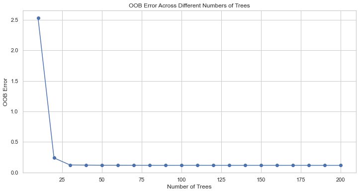

```python
X_train, X_test, y_train, y_test = train_test_split(X_transformed, target_ActualWeightFront, test_size=0.3, random_state=42)
# Number of trees to evaluate
n_trees = list(range(10, 201, 10))
oob_errors = []

for n in n_trees:
    model = RandomForestRegressor(n_estimators=n, oob_score=True, random_state=42, n_jobs=-1)
    model.fit(X_train, y_train)
    oob_errors.append(1 - model.oob_score_)

plt.figure(figsize=(12, 6))
plt.plot(n_trees, oob_errors, '-o')
plt.title('OOB Error Across Different Numbers of Trees')
plt.xlabel('Number of Trees')
plt.ylabel('OOB Error')
plt.show()
```

### 💡 Findings

When testing estimators let's use 30 as a point of reference.

Using this information let's try and get an idea of which models will work really well with this data.

```python
from sklearn.ensemble import AdaBoostRegressor, BaggingRegressor, ExtraTreesRegressor
from sklearn.tree import DecisionTreeRegressor
from sklearn.neighbors import KNeighborsRegressor
from sklearn.neural_network import MLPRegressor
from sklearn.linear_model import ElasticNet, BayesianRidge, ARDRegression, PassiveAggressiveRegressor, HuberRegressor, TheilSenRegressor, RANSACRegressor
from sklearn.svm import LinearSVR
from sklearn.kernel_ridge import KernelRidge
import pandas as pd
from sklearn.model_selection import KFold

from sklearn.ensemble import RandomForestRegressor, GradientBoostingRegressor
from sklearn.linear_model import LinearRegression, Ridge, Lasso
from sklearn.svm import SVR
import numpy as np

#Add medals to the best scoring algorithms
def append_medals(df):
    # For R2, higher is better
    top3_r2 = df['R2 Score'].nlargest(3).index
    df.at[top3_r2[0], 'R2 Score'] = str(df['R2 Score'].iloc[top3_r2[0]]) + ' 🏆'
    df.at[top3_r2[1], 'R2 Score'] = str(df['R2 Score'].iloc[top3_r2[1]]) + ' 🥈'
    df.at[top3_r2[2], 'R2 Score'] = str(df['R2 Score'].iloc[top3_r2[2]]) + ' 🥉'

    # For the rest, lower is better
    metrics = ['RMSE', 'MSE', 'MAE', 'MAPE', 'SMAPE']
    for metric in metrics:
        top3_indices = df[metric].nsmallest(3).index
        df.at[top3_indices[0], metric] = str(df[metric].iloc[top3_indices[0]]) + ' 🏆'
        df.at[top3_indices[1], metric] = str(df[metric].iloc[top3_indices[1]]) + ' 🥈'
        df.at[top3_indices[2], metric] = str(df[metric].iloc[top3_indices[2]]) + ' 🥉'

    return df

def mean_absolute_percentage_error(y_true, y_pred):
    y_true, y_pred = np.array(y_true), np.array(y_pred)
    return np.mean(np.abs((y_true - y_pred) / y_true)) * 100

def smape(y_true, y_pred):
    return 100 * np.mean(2 * np.abs(y_pred - y_true) / (np.abs(y_pred) + np.abs(y_true)))

def evaluate_models(models, X, y, k_folds=5):
    final_results = []

    kf = KFold(n_splits=k_folds, shuffle=True, random_state=42)

    for model in models:
        results = []
        for train_index, test_index in kf.split(X):
            X_train, X_test = X.iloc[train_index], X.iloc[test_index]
            y_train, y_test = y.iloc[train_index], y.iloc[test_index]

            model.fit(X_train, y_train)
            y_pred = model.predict(X_test)

            r2 = round(r2_score(y_test, y_pred),4)
            rmse = round(np.sqrt(mean_squared_error(y_test, y_pred)),4)
            mse = round(mean_squared_error(y_test, y_pred),4)
            mae = mean_absolute_error(y_test, y_pred)
            mape = mean_absolute_percentage_error(y_test, y_pred)
            smape_val = smape(y_test, y_pred)

            results.append([r2, rmse, mse, mae, mape, smape_val])

        # Calculate average scores
        avg_scores = [round(np.mean([result[i] for result in results]), 4) for i in range(len(results[0]))]
        final_results.append([type(model).__name__] + avg_scores)
        print("✔️ {}".format(type(model).__name__))
    columns = ["Model", "R2 Score", "RMSE", "MSE", "MAE", "MAPE", "SMAPE"]
    results_df = pd.DataFrame(final_results, columns=columns)

    # Append ✔️ to the best scores
    results_df = append_medals(results_df)

    return results_df

models = [
    # Ensemble Methods
    RandomForestRegressor(n_estimators=30, random_state=0),
    GradientBoostingRegressor(n_estimators=30, random_state=0),
    AdaBoostRegressor(n_estimators=30, random_state=0),
    BaggingRegressor(n_estimators=30, random_state=0),
    ExtraTreesRegressor(n_estimators=30, random_state=0),

    # Linear Models
    LinearRegression(),
    Ridge(),
    Lasso(),
    ElasticNet(),
    BayesianRidge(),
    ARDRegression(),
    PassiveAggressiveRegressor(),
    HuberRegressor(),
    TheilSenRegressor(),
    RANSACRegressor(),

    # SVM
    SVR(),
    LinearSVR(),

    # Neighbors
    KNeighborsRegressor(),

    # Neural Network
    MLPRegressor(hidden_layer_sizes=(100,), max_iter=500, random_state=0),

    # Tree-based
    DecisionTreeRegressor(),
    XGBRegressor(n_estimators=30, random_state=0),
    LGBMRegressor(n_estimators=30, random_state=0),

    # Kernel Ridge Regression
    KernelRidge(),


]
```

### Predicting Total

```python
y = target_ActualWeightTotal
X_transformed = data_prep_pipeline.fit_transform(X, y)

results_df_total = evaluate_models(models, X_transformed, y)
results_df_total
```

```
✔️ RandomForestRegressor
✔️ GradientBoostingRegressor
✔️ AdaBoostRegressor
✔️ BaggingRegressor
✔️ ExtraTreesRegressor
✔️ LinearRegression
✔️ Ridge
✔️ Lasso
✔️ ElasticNet
✔️ BayesianRidge
✔️ ARDRegression
✔️ PassiveAggressiveRegressor
✔️ HuberRegressor
✔️ TheilSenRegressor
✔️ RANSACRegressor
✔️ SVR
✔️ LinearSVR
✔️ KNeighborsRegressor
✔️ MLPRegressor
✔️ DecisionTreeRegressor
✔️ XGBRegressor
✔️ LGBMRegressor
✔️ KernelRidge
```

|  | Model | R2 Score | RMSE | MSE | MAE | MAPE | SMAPE |
| --- | --- | --- | --- | --- | --- | --- | --- |
| 0 | RandomForestRegressor | 0.8011 🥈 | 478.7839 🥈 | 230298.5194 🥈 | 290.2632 🥈 | 1.6181 🥈 | 1.6119 🥈 |
| 1 | GradientBoostingRegressor | 0.7269 | 563.3094 | 317832.8091 | 404.0855 | 2.2576 | 2.2482 |
| 2 | AdaBoostRegressor | 0.5724 | 705.6288 | 498249.4218 | 546.5403 | 3.0514 | 3.0409 |
| 3 | BaggingRegressor | 0.8011 🥉 | 478.8759 🥉 | 230345.9915 🥉 | 290.4994 🥉 | 1.6193 🥉 | 1.6131 🥉 |
| 4 | ExtraTreesRegressor | 0.7987 | 481.9655 | 233258.4131 | 288.942 🏆 | 1.6095 🏆 | 1.6037 🏆 |
| 5 | LinearRegression | 0.6614 | 627.4376 | 394391.666 | 459.6826 | 2.5602 | 2.5534 |
| 6 | Ridge | 0.6615 | 627.4257 | 394374.8146 | 459.6643 | 2.5601 | 2.5533 |
| 7 | Lasso | 0.6615 | 627.3773 | 394296.7737 | 459.4429 | 2.5588 | 2.5521 |
| 8 | ElasticNet | 0.6397 | 647.966 | 420133.1125 | 483.4911 | 2.6924 | 2.6869 |
| 9 | BayesianRidge | 0.6615 | 627.3957 | 394308.1675 | 459.5972 | 2.5597 | 2.553 |
| 10 | ARDRegression | 0.6616 | 627.3131 | 394215.7576 | 458.5653 | 2.5535 | 2.5469 |
| 11 | PassiveAggressiveRegressor | 0.6509 | 637.111 | 406790.6801 | 458.9319 | 2.5551 | 2.5466 |
| 12 | HuberRegressor | 0.6577 | 630.8401 | 398798.3915 | 456.886 | 2.5433 | 2.5362 |
| 13 | TheilSenRegressor | -4.0295 | 2332.2527 | 5723949.5496 | 926.8717 | 5.1273 | 6.4336 |
| 14 | RANSACRegressor | -2.5326 | 1658.0015 | 4200078.2619 | 723.1011 | 4.042 | 3.8826 |
| 15 | SVR | 0.1293 | 1008.7353 | 1018526.4218 | 806.9198 | 4.4698 | 4.4829 |
| 16 | LinearSVR | -216.1259 | 15903.7851 | 252932788.781 | 15866.4447 | 88.321 | 158.2088 |
| 17 | KNeighborsRegressor | 0.757 | 528.8404 | 281208.5656 | 325.7707 | 1.8184 | 1.8106 |
| 18 | MLPRegressor | -42.7834 | 7141.5165 | 51030007.1392 | 6199.4957 | 34.7312 | 45.495 |
| 19 | DecisionTreeRegressor | 0.7858 | 497.0054 | 248062.9565 | 295.3556 | 1.6451 | 1.6401 |
| 20 | XGBRegressor | 0.8059 🏆 | 473.5516 🏆 | 225130.7845 🏆 | 291.2641 | 1.6239 | 1.6177 |
| 21 | LGBMRegressor | 0.7844 | 499.2884 | 250318.1475 | 321.993 | 1.7957 | 1.7877 |
| 22 | KernelRidge | -283.0564 | 18186.9662 | 330774343.0359 | 18144.7583 | 101.3038 | 191.9926 |

### Predicting Front

```python
y = target_ActualWeightFront
X_transformed = data_prep_pipeline.fit_transform(X, y)

results_df_total = evaluate_models(models, X_transformed, y)
results_df_total
```

```
✔️ RandomForestRegressor
✔️ GradientBoostingRegressor
✔️ AdaBoostRegressor
✔️ BaggingRegressor
✔️ ExtraTreesRegressor
✔️ LinearRegression
✔️ Ridge
✔️ Lasso
✔️ ElasticNet
✔️ BayesianRidge
✔️ ARDRegression
✔️ PassiveAggressiveRegressor
✔️ HuberRegressor
✔️ TheilSenRegressor
✔️ RANSACRegressor
✔️ SVR
✔️ LinearSVR
✔️ KNeighborsRegressor
✔️ MLPRegressor
✔️ DecisionTreeRegressor
✔️ XGBRegressor
✔️ LGBMRegressor
✔️ KernelRidge
```

|  | Model | R2 Score | RMSE | MSE | MAE | MAPE | SMAPE |
| --- | --- | --- | --- | --- | --- | --- | --- |
| 0 | RandomForestRegressor | 0.8953 🏆 | 229.5118 🏆 | 53085.1121 🏆 | 130.2841 🥉 | 1.2182 🥈 | 1.2143 🥈 |
| 1 | GradientBoostingRegressor | 0.856 | 268.9559 | 73098.1024 | 179.3228 | 1.6784 | 1.6704 |
| 2 | AdaBoostRegressor | 0.7273 | 371.5134 | 138157.1979 | 272.4418 | 2.5413 | 2.5364 |
| 3 | BaggingRegressor | 0.8952 🥈 | 229.5995 🥈 | 53129.3674 🥈 | 130.0752 🏆 | 1.2162 🏆 | 1.2124 🏆 |
| 4 | ExtraTreesRegressor | 0.8903 | 234.6574 | 55478.9068 | 130.2439 🥈 | 1.2183 🥉 | 1.2145 🥉 |
| 5 | LinearRegression | 0.8335 | 289.4355 | 84430.4047 | 199.5315 | 1.8616 | 1.8533 |
| 6 | Ridge | 0.8334 | 289.4616 | 84442.4363 | 199.5924 | 1.8621 | 1.8539 |
| 7 | Lasso | 0.8332 | 289.6671 | 84553.998 | 200.0872 | 1.8667 | 1.8585 |
| 8 | ElasticNet | 0.8065 | 312.5823 | 98204.519 | 226.3124 | 2.1056 | 2.0976 |
| 9 | BayesianRidge | 0.8331 | 289.7846 | 84611.4152 | 199.9467 | 1.8652 | 1.857 |
| 10 | ARDRegression | 0.8332 | 289.6515 | 84555.3324 | 199.9103 | 1.8651 | 1.8569 |
| 11 | PassiveAggressiveRegressor | 0.8244 | 297.2945 | 88975.9839 | 199.3652 | 1.8592 | 1.8506 |
| 12 | HuberRegressor | 0.831 | 291.5693 | 85663.8733 | 196.1196 | 1.8327 | 1.8231 |
| 13 | TheilSenRegressor | -4.0925 | 1573.7107 | 2546774.668 | 535.9341 | 4.9417 | 6.5363 |
| 14 | RANSACRegressor | 0.7768 | 336.0078 | 113517.097 | 219.8252 | 2.0447 | 2.0403 |
| 15 | SVR | 0.3097 | 591.3392 | 349863.4979 | 441.7173 | 4.0401 | 4.0742 |
| 16 | LinearSVR | -148.773 | 8705.4732 | 75785957.276 | 8674.241 | 80.5311 | 134.9252 |
| 17 | KNeighborsRegressor | 0.8636 | 262.4784 | 69167.6763 | 156.3438 | 1.4572 | 1.452 |
| 18 | MLPRegressor | -20.4212 | 3289.0527 | 10837852.3505 | 2582.4927 | 23.9279 | 28.698 |
| 19 | DecisionTreeRegressor | 0.8917 | 233.0712 | 54862.3685 | 131.552 | 1.2305 | 1.2261 |
| 20 | XGBRegressor | 0.8932 🥉 | 231.5479 🥉 | 54148.5461 🥉 | 131.659 | 1.2321 | 1.2269 |
| 21 | LGBMRegressor | 0.8814 | 244.2603 | 60211.5009 | 148.7239 | 1.3882 | 1.382 |
| 22 | KernelRidge | -234.6551 | 10917.1252 | 119188290.7061 | 10891.1801 | 101.5747 | 190.5893 |

### Predicting Back

```python
y = target_ActualWeightBack
X_transformed = data_prep_pipeline.fit_transform(X, y)

results_df_total = evaluate_models(models, X_transformed, y)
results_df_total
```

```
✔️ RandomForestRegressor
✔️ GradientBoostingRegressor
✔️ AdaBoostRegressor
✔️ BaggingRegressor
✔️ ExtraTreesRegressor
✔️ LinearRegression
✔️ Ridge
✔️ Lasso
✔️ ElasticNet
✔️ BayesianRidge
✔️ ARDRegression
✔️ PassiveAggressiveRegressor
✔️ HuberRegressor
✔️ TheilSenRegressor
✔️ RANSACRegressor
✔️ SVR
✔️ LinearSVR
✔️ KNeighborsRegressor
✔️ MLPRegressor
✔️ DecisionTreeRegressor
✔️ XGBRegressor
✔️ LGBMRegressor
✔️ KernelRidge
```

|  | Model | R2 Score | RMSE | MSE | MAE | MAPE | SMAPE |
| --- | --- | --- | --- | --- | --- | --- | --- |
| 0 | RandomForestRegressor | 0.7872 🥉 | 410.7583 🥉 | 169074.8226 🥉 | 244.1078 🥉 | 3.4455 🥉 | 3.4046 🥉 |
| 1 | GradientBoostingRegressor | 0.6762 | 507.7242 | 258141.6621 | 358.9169 | 5.0233 | 4.9609 |
| 2 | AdaBoostRegressor | 0.523 | 615.0411 | 379359.7921 | 462.0963 | 6.5471 | 6.4033 |
| 3 | BaggingRegressor | 0.7879 🥈 | 410.0674 🥈 | 168522.2289 🥈 | 243.7857 🥈 | 3.4402 🥈 | 3.4002 🥈 |
| 4 | ExtraTreesRegressor | 0.7827 | 415.1815 | 172686.9054 | 244.5569 | 3.4479 | 3.4095 |
| 5 | LinearRegression | 0.471 | 648.7058 | 421243.5064 | 505.3203 | 7.0058 | 6.9315 |
| 6 | Ridge | 0.4711 | 648.6939 | 421226.9838 | 505.336 | 7.0059 | 6.9317 |
| 7 | Lasso | 0.4713 | 648.5511 | 421031.8387 | 505.5588 | 7.0075 | 6.9341 |
| 8 | ElasticNet | 0.4419 | 666.7692 | 444789.351 | 523.9646 | 7.2307 | 7.1718 |
| 9 | BayesianRidge | 0.4712 | 648.6101 | 421097.628 | 505.7998 | 7.0098 | 6.9371 |
| 10 | ARDRegression | 0.4717 | 648.4037 | 420813.7174 | 505.6685 | 7.0061 | 6.9347 |
| 11 | PassiveAggressiveRegressor | 0.4513 | 661.1534 | 437463.4029 | 507.0926 | 7.0274 | 6.9561 |
| 12 | HuberRegressor | 0.4649 | 652.5355 | 426176.4484 | 505.1507 | 7.0135 | 6.9393 |
| 13 | TheilSenRegressor | -0.4549 | 1056.4699 | 1147993.0817 | 666.9793 | 9.2603 | 10.4162 |
| 14 | RANSACRegressor | 0.0397 | 872.8997 | 763874.9117 | 651.523 | 9.0958 | 8.9843 |
| 15 | SVR | 0.0616 | 865.4469 | 749460.4848 | 667.5756 | 9.1126 | 9.2104 |
| 16 | LinearSVR | -32.7431 | 5184.405 | 26879375.009 | 5104.7977 | 70.5015 | 109.1993 |
| 17 | KNeighborsRegressor | 0.7301 | 462.1175 | 214393.8754 | 277.6469 | 3.9305 | 3.8735 |
| 18 | MLPRegressor | -1.4216 | 1383.7872 | 1920399.3398 | 1065.5495 | 14.9436 | 16.3003 |
| 19 | DecisionTreeRegressor | 0.7676 | 428.8647 | 184443.4037 | 249.5108 | 3.5149 | 3.4748 |
| 20 | XGBRegressor | 0.7918 🏆 | 406.6225 🏆 | 165583.6396 🏆 | 243.4098 🏆 | 3.4342 🏆 | 3.3929 🏆 |
| 21 | LGBMRegressor | 0.7686 | 429.0368 | 184357.0731 | 272.2088 | 3.8217 | 3.7785 |
| 22 | KernelRidge | -66.1968 | 7316.1791 | 53527705.4363 | 7273.5247 | 101.8426 | 188.0728 |

### 💡 Findings

We only need to predict the two best outputs, and then we can infer the third.  
Although the R2 score is very similar between the Back and Total, the SMAPE score for the Total is much better.  
Therefore we will try use the random forest for the front and XGBoost for the total.

### 👨‍🔬 Feature Engineering

### Feature Engineer Front Model

```python
X = training.drop(columns= targetColumns  + ['TruckSID'])
y = target_ActualWeightFront
X_transformed = data_prep_pipeline.fit_transform(X, y)
X_train, X_test, y_train, y_test = train_test_split(X_transformed, y, test_size=0.3, random_state=0)
```

### 🧠 A good idea

Let's get a baseline for how well our model is performing.

```python
model = XGBRegressor(random_state=42)
scores = -cross_val_score(model, X_train, y_train, cv=5, scoring="neg_mean_absolute_error")
print(scores)
print("MAE score: {}".format(np.mean(scores)))
```

```
[109.83327439 140.11404666 123.61776288 129.49583773 140.21197477]
MAE score: 128.65457928631758
```

### 🧠 A good idea

Let's start by making as many features as we can think of, then then start reducing them until we get the perfect score.

```python
def FE(Training):
    '''
    # Position Analysis:
    Training['sum_wheelbase_per_front_axle_position'] = Training.groupby('FrontAxlePosition')['WheelBase'].transform('sum')
    Training['max_wheelbase_per_front_axle_position'] = Training.groupby('FrontAxlePosition')['WheelBase'].transform('max')
    Training['min_wheelbase_per_front_axle_position'] = Training.groupby('FrontAxlePosition')['WheelBase'].transform('min')
    Training['std_wheelbase_per_front_axle_position'] = Training.groupby('FrontAxlePosition')['WheelBase'].transform('std')

    Training['sum_overhang_per_front_axle_position'] = Training.groupby('FrontAxlePosition')['Overhang'].transform('sum')
    Training['max_overhang_per_front_axle_position'] = Training.groupby('FrontAxlePosition')['Overhang'].transform('max')
    Training['min_overhang_per_front_axle_position'] = Training.groupby('FrontAxlePosition')['Overhang'].transform('min')
    Training['std_overhang_per_front_axle_position'] = Training.groupby('FrontAxlePosition')['Overhang'].transform('std')
    Training['avg_wheelbase_per_front_axle_position'] = Training.groupby('FrontAxlePosition')['WheelBase'].transform('mean')
    Training['avg_overhang_per_front_axle_position'] = Training.groupby('FrontAxlePosition')['Overhang'].transform('mean')

    # Position Analysis (Wheelbase and Overhang):
    Training['sum_wheelbase_per_front_axle_position'] = Training.groupby('FrontAxlePosition')['WheelBase'].transform('sum')
    Training['max_wheelbase_per_front_axle_position'] = Training.groupby('FrontAxlePosition')['WheelBase'].transform('max')
    Training['min_wheelbase_per_front_axle_position'] = Training.groupby('FrontAxlePosition')['WheelBase'].transform('min')
    Training['std_wheelbase_per_front_axle_position'] = Training.groupby('FrontAxlePosition')['WheelBase'].transform('std')

    Training['sum_overhang_per_front_axle_position'] = Training.groupby('FrontAxlePosition')['Overhang'].transform('sum')
    Training['max_overhang_per_front_axle_position'] = Training.groupby('FrontAxlePosition')['Overhang'].transform('max')
    Training['min_overhang_per_front_axle_position'] = Training.groupby('FrontAxlePosition')['Overhang'].transform('min')
    Training['std_overhang_per_front_axle_position'] = Training.groupby('FrontAxlePosition')['Overhang'].transform('std')
    '''

    # Interaction Features:
    Training['Engine_Transmission'] = Training['Engine'] * Training['Transmission']
    Training['TransmissionFamily_EngineFamily'] = Training['TransmissionFamily'] * Training['EngineFamily']

    # Polynomial Features for numeric variables:
    Training['WheelBase_squared'] = Training['WheelBase'] ** 2
    Training['Overhang_squared'] = Training['Overhang'] ** 2

    # Ratio Features:
    Training['Front_to_Rear_Wheels'] = Training['FrontWheels'] / (Training['RearWheels'] + 0.001)  # Add a small number to avoid division by zero
    Training['WheelBase_to_Overhang'] = Training['WheelBase'] / (Training['Overhang'] + 0.001)

    # Aggregated Features for TransmissionFamily and EngineFamily:
    Training['avg_WheelBase_per_TransmissionFamily'] = Training.groupby('TransmissionFamily')['WheelBase'].transform('mean')
    Training['avg_Overhang_per_EngineFamily'] = Training.groupby('EngineFamily')['Overhang'].transform('mean')

    # Features based on other columns:
    Training['sum_WheelBase_per_Engine'] = Training.groupby('Engine')['WheelBase'].transform('sum')
    Training['max_Overhang_per_Transmission'] = Training.groupby('Transmission')['Overhang'].transform('max')

    #Training['Transmission_EngineFamily'] = Training['Transmission'] * Training['EngineFamily']

    '''
    # Standard deviation relative to the mean (Coefficient of Variation):
    Training['cv_WheelBase_per_FrontAxlePosition'] = Training['std_wheelbase_per_front_axle_position'] / (Training['avg_wheelbase_per_front_axle_position'] + 0.001)
    Training['cv_Overhang_per_FrontAxlePosition'] = Training['std_overhang_per_front_axle_position'] / (Training['avg_overhang_per_front_axle_position'] + 0.001)

    #Interactions with Top Features:
    Training['Engine_TransmissionFamily'] = Training['Engine'] * Training['TransmissionFamily']


    #Aggregations with Other Features:
    Training['mean_WheelBase_per_Transmission'] = Training.groupby('Transmission')['WheelBase'].transform('mean')
    Training['mean_Overhang_per_EngineFamily'] = Training.groupby('EngineFamily')['Overhang'].transform('mean')
    Training['sum_FrontWheels_per_Transmission'] = Training.groupby('Transmission')['FrontWheels'].transform('sum')

    #Cumulative Sum and Diff Features:
    # Assuming some sort of order (like time), adjust as necessary
    Training['cumsum_WheelBase'] = Training['WheelBase'].cumsum()
    Training['cumsum_Overhang'] = Training['Overhang'].cumsum()
    Training['diff_WheelBase'] = Training['WheelBase'].diff()
    Training['diff_Overhang'] = Training['Overhang'].diff()

    #Bin-based Features:
    Training['WheelBase_bins'] = pd.cut(Training['WheelBase'], bins=5, labels=False)  # 5 bins, can adjust
    Training['mean_Overhang_per_WheelBase_bins'] = Training.groupby('WheelBase_bins')['Overhang'].transform('mean')

    '''

    return Training
```

```python
X_train_fe = FE(X_train)
X_test_fe = FE(X_test)
```

### 🧠 A good idea

All the features where graphed to help find the most useful ones.

```
[109.93013091 138.35848818 126.57804054 129.82614548 140.92304951]
Mean: 129.12317092483107
```

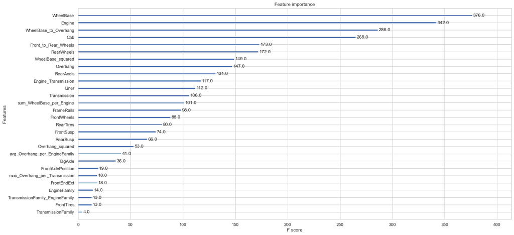

```python
model = XGBRegressor(random_state=42)
model.fit(X_train_fe, y_train)
scores = -cross_val_score(model, X_train_fe, y_train, cv=5, scoring="neg_mean_absolute_error")
print(scores)
print("Mean:", scores.mean())
xgb.plot_importance(model)
plt.show()
```

```python
feature_importances = model.feature_importances_

# Create a DataFrame for better manipulation
importance_df = pd.DataFrame({
    'Feature': X_train.columns,
    'Importance': feature_importances
})
importance_df_sorted =  importance_df.sort_values(by='Importance', ascending=False)
importance_df_sorted.to_csv('importance_df_sorted.csv', index=False)
importance_df_sorted
```

|  | Feature | Importance |
| --- | --- | --- |
| 18 | TransmissionFamily | 0.368260 |
| 1 | Transmission | 0.233128 |
| 17 | EngineFamily | 0.129587 |
| 0 | Engine | 0.105301 |
| 16 | TagAxle | 0.042307 |
| 14 | FrontWheels | 0.041407 |
| 6 | Liner | 0.019834 |
| 24 | WheelBase_to_Overhang | 0.007705 |
| 4 | Overhang | 0.006767 |
| 3 | WheelBase | 0.006328 |
| 8 | Cab | 0.004250 |
| 28 | max_Overhang_per_Transmission | 0.004218 |
| 26 | avg_Overhang_per_EngineFamily | 0.003950 |
| 21 | WheelBase_squared | 0.003193 |
| 12 | RearWheels | 0.002884 |
| 5 | FrameRails | 0.002641 |
| 10 | RearSusp | 0.002446 |
| 19 | Engine_Transmission | 0.002134 |
| 23 | Front_to_Rear_Wheels | 0.002083 |
| 22 | Overhang_squared | 0.002062 |
| 13 | RearTires | 0.001861 |
| 20 | TransmissionFamily_EngineFamily | 0.001588 |
| 11 | FrontSusp | 0.001357 |
| 9 | RearAxels | 0.001317 |
| 15 | FrontTires | 0.001300 |
| 27 | sum_WheelBase_per_Engine | 0.000877 |
| 2 | FrontAxlePosition | 0.000817 |
| 7 | FrontEndExt | 0.000398 |
| 25 | avg_WheelBase_per_TransmissionFamily | 0.000000 |

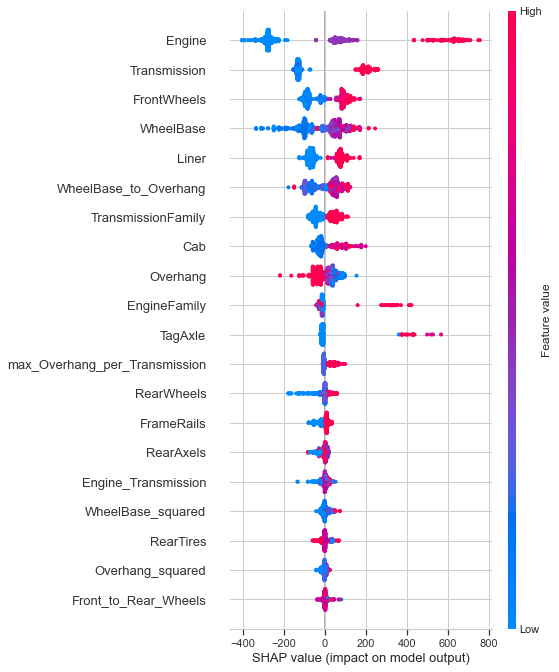

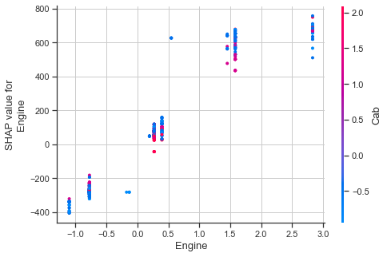

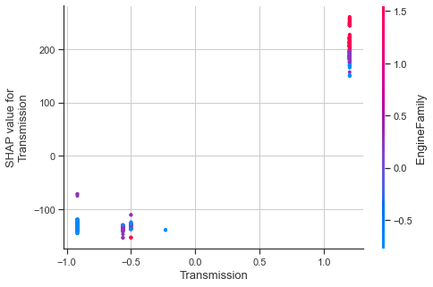

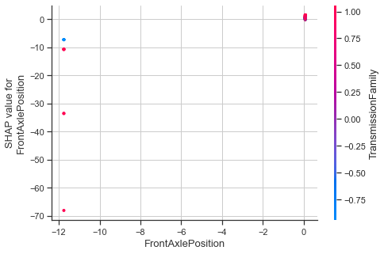

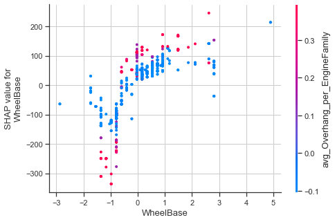

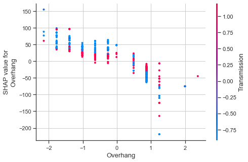

```python
model = xgb.train({"learning_rate": 0.1}, xgb.DMatrix(X_train_fe, label=y_train), 100)

# Specifically for XGBoost, you can use the TreeExplainer which works best for tree-based models
explainer = shap.TreeExplainer(model)

# Compute SHAP values for a sample of the test set
shap_values = explainer.shap_values(X_test_fe)

# Visualize the first prediction's explanation
shap.initjs()
shap.force_plot(explainer.expected_value, shap_values[0], X_test_fe.iloc[0])

shap.summary_plot(shap_values, X_test_fe)
# For a dependence plot for a specific feature
for i in range(5):
    feature_name = X_test.columns[i]  # get the name of the first feature
    shap.dependence_plot(feature_name, shap_values, X_test_fe)
```

### 🧠 A good idea

Features where filtered out based on an arbitrary number I fiddled with until I got the best results

```python
# Filter out features with importance less importance
#0.001927
selected_features = importance_df[importance_df['Importance'] >= 0.001927]['Feature'].tolist()

# Subset the dataset
X_train_selected = X_train[selected_features]
X_test_selected = X_test[selected_features]
```

```python
model = XGBRegressor(random_state=42)  # or xgb.XGBClassifier() for classification
scores = -cross_val_score(model, X_train_selected, y_train, cv=5, scoring="neg_mean_absolute_error")

print(scores)
print("Mean:", scores.mean())
```

```
[108.81307802 141.39698849 126.0712178  130.55963894 137.75222762]
Mean: 128.9186301731419
```

### 💡 Findings

```python
X_train_selected.to_csv('X_train_selected.csv', index=False)
front_selected_columns = X_train_selected.columns
front_selected_columns
```

```
Index(['Engine', 'Transmission', 'WheelBase', 'Overhang', 'FrameRails',
       'Liner', 'Cab', 'RearSusp', 'RearWheels', 'FrontWheels', 'TagAxle',
       'EngineFamily', 'TransmissionFamily', 'Engine_Transmission',
       'WheelBase_squared', 'Overhang_squared', 'Front_to_Rear_Wheels',
       'WheelBase_to_Overhang', 'avg_Overhang_per_EngineFamily',
       'max_Overhang_per_Transmission'],
      dtype='object')
```

### 💡 Findings

These were deemed the important features

```python
X_transformed_fe = FE(X_transformed)
X_transformed_fe = X_transformed_fe[front_selected_columns]
X_transformed_fe
```

|  | Engine | Transmission | WheelBase | Overhang | FrameRails | Liner | Cab | RearSusp | RearWheels | FrontWheels | TagAxle | EngineFamily | TransmissionFamily | Engine_Transmission | WheelBase_squared | Overhang_squared | Front_to_Rear_Wheels | WheelBase_to_Overhang | avg_Overhang_per_EngineFamily | max_Overhang_per_Transmission |
| --- | --- | --- | --- | --- | --- | --- | --- | --- | --- | --- | --- | --- | --- | --- | --- | --- | --- | --- | --- | --- |
| 0 | -0.775150 | 1.199613 | 2.620206 | 0.867729 | 0.647233 | 1.118745 | -0.946623 | 0.251651 | 1.262227 | 1.224191 | -0.15539 | -0.774318 | 1.059240 | -0.929880 | 6.865481 | 0.752953 | 0.969098 | 3.016139 | -0.089933 | 2.373981 |
| 1 | -0.775150 | -0.917003 | -1.545882 | -1.391651 | 0.647233 | 1.118745 | 1.193472 | 0.251651 | -0.317981 | 0.801290 | -0.15539 | -0.774318 | -0.944073 | 0.710815 | 2.389750 | 1.936692 | -2.527878 | 1.111625 | -0.089933 | 1.244292 |
| 2 | 0.194674 | -0.917003 | 0.537162 | -1.391651 | 0.647233 | 1.118745 | -0.408809 | 0.251651 | 1.262227 | 1.224191 | -0.15539 | 0.283715 | -0.944073 | -0.178516 | 0.288543 | 1.936692 | 0.969098 | -0.386267 | -0.073598 | 1.244292 |
| 3 | 0.270655 | 1.199613 | 0.726530 | 0.867729 | 0.647233 | 1.118745 | -0.946623 | 0.251651 | 1.262227 | 1.224191 | -0.15539 | 0.283715 | 1.059240 | 0.324682 | 0.527846 | 0.752953 | 0.969098 | 0.836314 | -0.073598 | 2.373981 |
| 4 | 1.580971 | 1.199613 | 1.484000 | 0.867729 | 0.647233 | 1.118745 | -0.408809 | 0.251651 | -0.317981 | -0.856580 | -0.15539 | 1.551007 | 1.059240 | 1.896553 | 2.202257 | 0.752953 | 2.702304 | 1.708244 | 0.409488 | 2.373981 |
| ... | ... | ... | ... | ... | ... | ... | ... | ... | ... | ... | ... | ... | ... | ... | ... | ... | ... | ... | ... | ... |
| 2639 | -0.175652 | -0.231394 | 0.158427 | 0.867729 | 0.647233 | -0.906376 | -0.946623 | -3.511279 | 1.691276 | 1.224191 | -0.15539 | -0.774318 | -0.944073 | 0.040645 | 0.025099 | 0.752953 | 0.723399 | 0.182367 | -0.089933 | 0.867729 |
| 2640 | 0.270655 | 1.199613 | 0.158427 | -1.015088 | 0.647233 | 1.118745 | 2.089485 | 0.251651 | 1.262227 | 1.224191 | -0.15539 | 0.283715 | 1.059240 | 0.324682 | 0.025099 | 1.030403 | 0.969098 | -0.156226 | -0.073598 | 2.373981 |
| 2641 | 0.270655 | 1.199613 | 0.915898 | -0.638524 | 0.647233 | -0.906376 | -0.946623 | 0.517296 | 1.262227 | 1.224191 | -0.15539 | 0.283715 | 1.059240 | 0.324682 | 0.838868 | 0.407713 | 0.969098 | -1.436647 | -0.073598 | 2.373981 |
| 2642 | -0.775150 | -0.917003 | 0.915898 | -2.144777 | 0.647233 | 1.118745 | -0.408809 | 0.251651 | -0.721544 | -1.037440 | -0.15539 | -0.774318 | -0.944073 | 0.710815 | 0.838868 | 4.600069 | 1.439802 | -0.427235 | -0.089933 | 1.244292 |
| 2643 | -0.775150 | -0.917003 | -0.599043 | 0.867729 | 0.647233 | -0.906376 | -0.946623 | 0.251651 | -0.317981 | -0.856580 | -0.15539 | -0.774318 | -0.944073 | 0.710815 | 0.358853 | 0.752953 | 2.702304 | -0.689563 | -0.089933 | 1.244292 |

2644 rows × 20 columns

### 🧠 A good idea

Let's being optimizing the hyperparameters.  
We will use optuna to make this process really easy and reliable.

```python
import optuna
from sklearn.model_selection import train_test_split
from sklearn.metrics import mean_absolute_error

X = X_transformed_fe
y = target_ActualWeightFront

def objective(trial):
    # Define the hyperparameter search space
    params = {
        "n_estimators": trial.suggest_int("n_estimators", 10, 1000),
        "learning_rate": trial.suggest_loguniform("learning_rate", 0.01, 0.3),
        "max_depth": trial.suggest_int("max_depth", 1, 10),
        "reg_lambda": trial.suggest_loguniform("reg_lambda", 1e-9, 100),
        "subsample": trial.suggest_float("subsample", 0.1, 1),
        "colsample_bytree": trial.suggest_float("colsample_bytree", 0.1, 1),
        "gamma": trial.suggest_float("gamma", 0, 1),
        "min_child_weight": trial.suggest_int("min_child_weight", 1, 10),
    }

    # Split the data into train and validation sets
    X_train, X_val, y_train, y_val = train_test_split(X, y, test_size=0.3, random_state=42)

    # Create and train the XGBRegressor with the suggested hyperparameters
    model = XGBRegressor(**params, eval_metric='mae',random_state=42,n_jobs=1)
    model.fit(X_train, y_train, eval_set=[(X_val, y_val)], early_stopping_rounds=50, verbose=False)

    # Calculate the MAE on the validation set
    y_pred = model.predict(X_val)
    mae = mean_absolute_error(y_val, y_pred)

    return mae

# Create a study object and specify that the goal is to minimize the objective function
study = optuna.create_study(direction="minimize")  # We want to minimize the MAE
study.optimize(objective, n_trials=100)

# Get the best hyperparameters and their corresponding MAE
best_params = study.best_params
best_score = study.best_value

print("Best Hyperparameters:", best_params)
print("Best Score (MAE):", best_score)
```

```
[I 2023-08-24 16:15:16,682] A new study created in memory with name: no-name-447db891-dc4b-4962-abde-053589ea984a
[I 2023-08-24 16:15:18,196] Trial 0 finished with value: 130.19256853156486 and parameters: {'n_estimators': 427, 'learning_rate': 0.01694322791220609, 'max_depth': 9, 'reg_lambda': 4.642992315604673e-08, 'subsample': 0.5430464794467578, 'colsample_bytree': 0.539580317832827, 'gamma': 0.859380117291…
[I 2023-08-24 16:15:18,562] Trial 1 finished with value: 149.17364240593514 and parameters: {'n_estimators': 987, 'learning_rate': 0.05583144868139609, 'max_depth': 4, 'reg_lambda': 0.0007207551588320399, 'subsample': 0.19117932324088788, 'colsample_bytree': 0.14517476916778466, 'gamma': 0.511959985…
[I 2023-08-24 16:15:18,977] Trial 2 finished with value: 157.33428078754724 and parameters: {'n_estimators': 694, 'learning_rate': 0.16141480047356932, 'max_depth': 1, 'reg_lambda': 0.000400560234584523, 'subsample': 0.7553035840162515, 'colsample_bytree': 0.31118811713172034, 'gamma': 0.63947381473…
[I 2023-08-24 16:15:19,241] Trial 3 finished with value: 209.18283734453715 and parameters: {'n_estimators': 184, 'learning_rate': 0.033828014704012734, 'max_depth': 6, 'reg_lambda': 35.460817982287196, 'subsample': 0.22655742578882, 'colsample_bytree': 0.9947108783634383, 'gamma': 0.636178502346690…
[I 2023-08-24 16:15:19,372] Trial 4 finished with value: 168.26681433997166 and parameters: {'n_estimators': 97, 'learning_rate': 0.07684312894536911, 'max_depth': 2, 'reg_lambda': 0.00023523172991973153, 'subsample': 0.24554563335895155, 'colsample_bytree': 0.7433512588461734, 'gamma': 0.3493757497…
[I 2023-08-24 16:15:19,816] Trial 5 finished with value: 190.7940252577928 and parameters: {'n_estimators': 374, 'learning_rate': 0.026802783735618087, 'max_depth': 1, 'reg_lambda': 0.002640864182571518, 'subsample': 0.22923387449059857, 'colsample_bytree': 0.4807795360902918, 'gamma': 0.54687014636…
[I 2023-08-24 16:15:21,590] Trial 6 finished with value: 151.7809990947733 and parameters: {'n_estimators': 666, 'learning_rate': 0.017022375766501244, 'max_depth': 3, 'reg_lambda': 5.80722520758997, 'subsample': 0.2668261507282023, 'colsample_bytree': 0.7762762427457641, 'gamma': 0.2557992655594511…
[I 2023-08-24 16:15:23,567] Trial 7 finished with value: 126.28322772355163 and parameters: {'n_estimators': 485, 'learning_rate': 0.14616584294881171, 'max_depth': 10, 'reg_lambda': 4.351919906383583e-07, 'subsample': 0.6647414396858334, 'colsample_bytree': 0.3603084324589827, 'gamma': 0.7070866545…
[I 2023-08-24 16:15:24,287] Trial 8 finished with value: 132.29397729061714 and parameters: {'n_estimators': 289, 'learning_rate': 0.21183914664751136, 'max_depth': 10, 'reg_lambda': 1.900350927283664e-08, 'subsample': 0.40067638126672256, 'colsample_bytree': 0.37705908177694214, 'gamma': 0.84496245…
[I 2023-08-24 16:15:24,595] Trial 9 finished with value: 2953.0243015241263 and parameters: {'n_estimators': 112, 'learning_rate': 0.011543028586996733, 'max_depth': 10, 'reg_lambda': 1.4005247910141336, 'subsample': 0.38540664844909833, 'colsample_bytree': 0.9005338089375228, 'gamma': 0.29600702136…
[I 2023-08-24 16:15:25,894] Trial 10 finished with value: 129.0891180927267 and parameters: {'n_estimators': 601, 'learning_rate': 0.10738937856302742, 'max_depth': 7, 'reg_lambda': 1.3961643409257602e-09, 'subsample': 0.9792305572494798, 'colsample_bytree': 0.14040184364522096, 'gamma': 0.101614517…
[I 2023-08-24 16:15:27,227] Trial 11 finished with value: 130.22966929707178 and parameters: {'n_estimators': 633, 'learning_rate': 0.11748746958841838, 'max_depth': 8, 'reg_lambda': 1.7222835997059082e-09, 'subsample': 0.9170290115301953, 'colsample_bytree': 0.14777113387123342, 'gamma': 0.04430065…
[I 2023-08-24 16:15:27,680] Trial 12 finished with value: 125.02926120710012 and parameters: {'n_estimators': 540, 'learning_rate': 0.23933505844382938, 'max_depth': 7, 'reg_lambda': 4.2948162244901355e-07, 'subsample': 0.995939219397985, 'colsample_bytree': 0.2781545625677888, 'gamma': 0.0232296228…
[I 2023-08-24 16:15:28,036] Trial 13 finished with value: 128.69169897276447 and parameters: {'n_estimators': 799, 'learning_rate': 0.26804303433234294, 'max_depth': 5, 'reg_lambda': 3.3879665047053345e-06, 'subsample': 0.7896003458737888, 'colsample_bytree': 0.33758652856430055, 'gamma': 0.99117611…
[I 2023-08-24 16:15:28,512] Trial 14 finished with value: 130.77471662468514 and parameters: {'n_estimators': 482, 'learning_rate': 0.2696438604403985, 'max_depth': 8, 'reg_lambda': 1.6839154281939031e-06, 'subsample': 0.7654467475983061, 'colsample_bytree': 0.2553903079548, 'gamma': 0.4004691411794…
[I 2023-08-24 16:15:28,944] Trial 15 finished with value: 128.86258388106108 and parameters: {'n_estimators': 309, 'learning_rate': 0.16623073886439377, 'max_depth': 6, 'reg_lambda': 1.0290580920873925e-06, 'subsample': 0.6710181615608674, 'colsample_bytree': 0.43994069969365635, 'gamma': 0.14718156…
```

[output cut: 84 more lines]

```
Best Hyperparameters: {'n_estimators': 764, 'learning_rate': 0.046809573194204264, 'max_depth': 6, 'reg_lambda': 2.2668865431435495e-09, 'subsample': 0.9185383263185233, 'colsample_bytree': 0.342001004337618, 'gamma': 0.46429146355407125, 'min_child_weight': 1}
Best Score (MAE): 124.80943010075566
```

### Feature Engineer Total Model

### 🧠 A good idea

Let's get a baseline for how well our model is performing.

```python
X = training.drop(columns= targetColumns  + ['TruckSID'])
y = target_ActualWeightTotal
X_transformed = data_prep_pipeline.fit_transform(X, y)
X_train, X_test, y_train, y_test = train_test_split(X_transformed, y, test_size=0.3, random_state=1)
model = XGBRegressor()
scores = -cross_val_score(model, X_train, y_train, cv=5, scoring="neg_mean_absolute_error")
print(scores)
print("MAE score: {}".format(np.mean(scores)))
```

```
[306.28804635 280.11694204 300.64648174 289.98769003 280.72701119]
MAE score: 291.5532342694257
```

```
[307.162339   278.79971759 297.96208562 289.35171822 288.43561286]
Mean: 292.3422946579392
```

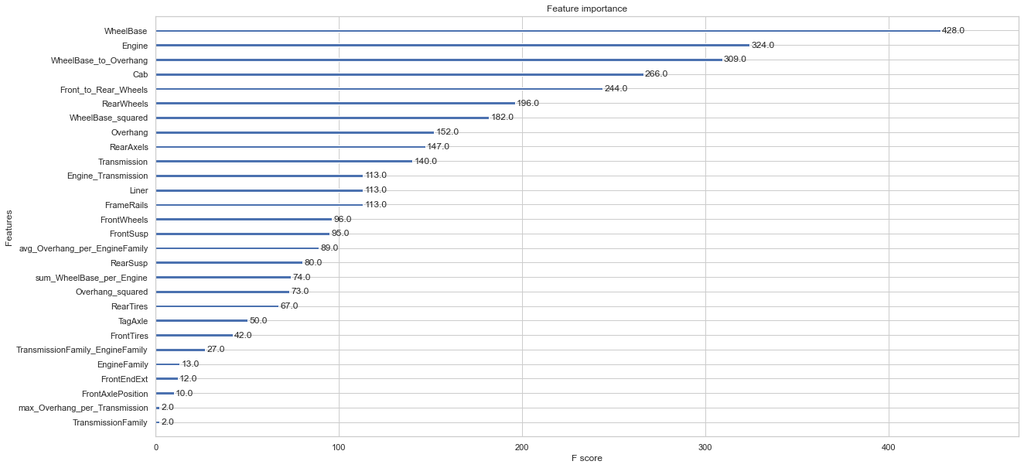

```python
X_train_fe = FE(X_train)
X_test_fe = FE(X_test)

model = XGBRegressor(random_state=42)
model.fit(X_train_fe, y_train)
scores = -cross_val_score(model, X_train_fe, y_train, cv=5, scoring="neg_mean_absolute_error")

print(scores)
print("Mean:", scores.mean())
xgb.plot_importance(model)
plt.show()
```

```python
feature_importances = model.feature_importances_

# Create a DataFrame for better manipulation
importance_df = pd.DataFrame({
    'Feature': X_train.columns,
    'Importance': feature_importances
})
importance_df_sorted =  importance_df.sort_values(by='Importance', ascending=False)
importance_df_sorted.to_csv('importance_df_sorted.csv', index=False)
importance_df_sorted
```

|  | Feature | Importance |
| --- | --- | --- |
| 17 | EngineFamily | 0.610977 |
| 18 | TransmissionFamily | 0.193234 |
| 1 | Transmission | 0.058836 |
| 12 | RearWheels | 0.033532 |
| 16 | TagAxle | 0.018143 |
| 13 | RearTires | 0.011649 |
| 27 | sum_WheelBase_per_Engine | 0.007636 |
| 4 | Overhang | 0.007139 |
| 6 | Liner | 0.006805 |
| 21 | WheelBase_squared | 0.006624 |
| 24 | WheelBase_to_Overhang | 0.006261 |
| 0 | Engine | 0.006041 |
| 3 | WheelBase | 0.003928 |
| 11 | FrontSusp | 0.003525 |
| 28 | max_Overhang_per_Transmission | 0.003510 |
| 15 | FrontTires | 0.003481 |
| 22 | Overhang_squared | 0.002605 |
| 23 | Front_to_Rear_Wheels | 0.002384 |
| 9 | RearAxels | 0.002239 |
| 8 | Cab | 0.001929 |
| 14 | FrontWheels | 0.001741 |
| 19 | Engine_Transmission | 0.001671 |
| 10 | RearSusp | 0.001582 |
| 26 | avg_Overhang_per_EngineFamily | 0.001364 |
| 2 | FrontAxlePosition | 0.001027 |
| 5 | FrameRails | 0.001025 |
| 7 | FrontEndExt | 0.000698 |
| 20 | TransmissionFamily_EngineFamily | 0.000417 |
| 25 | avg_WheelBase_per_TransmissionFamily | 0.000000 |

```python
selected_features = importance_df[importance_df['Importance'] >= 0.0001]['Feature'].tolist()

# Subset the dataset
X_train_selected = X_train[selected_features]
X_test_selected = X_test[selected_features]
```

```python
model = XGBRegressor(random_state=42)
model.fit(X_train_selected, y_train)
y_pred = model.predict(X_test_selected)
scores = -cross_val_score(model, X_train_selected, y_train, cv=5, scoring="neg_mean_absolute_error")

print(scores)
print("Mean:", scores.mean())
```

```
[307.162339   278.79971759 297.96208562 289.35171822 288.43561286]
Mean: 292.3422946579392
```

```python
pca = PCA(n_components=0.95)  # Retain 95% of the variance
X_train_pca = pca.fit_transform(X_train_selected)
X_val_pca = pca.transform(X_test_selected)
```

```python
model = XGBRegressor(random_state=42)  # or xgb.XGBClassifier() for classification
model.fit(X_train_pca, y_train)
y_pred = model.predict(X_val_pca)
scores = -cross_val_score(model, X_train_selected, y_train, cv=5, scoring="neg_mean_absolute_error")

print(scores)
print("Mean:", scores.mean())
```

```
[307.162339   278.79971759 297.96208562 289.35171822 288.43561286]
Mean: 292.3422946579392
```

### 💡 Findings

I was unsuccessful in creating a useful combination of features, adding extra dimensions didn't help the model and reducing existing dimensions didn't help either.

```python
X_train_selected.to_csv('X_train_selected_total.csv', index=False)
```

```python
X = X_transformed
y = target_ActualWeightTotal

def objective(trial):
    # Define the hyperparameter search space
    params = {
        "n_estimators": trial.suggest_int("n_estimators", 10, 1000),
        "learning_rate": trial.suggest_loguniform("learning_rate", 0.01, 0.3),
        "max_depth": trial.suggest_int("max_depth", 1, 10),
        "reg_lambda": trial.suggest_loguniform("reg_lambda", 1e-9, 100),
        "subsample": trial.suggest_float("subsample", 0.1, 1),
        "colsample_bytree": trial.suggest_float("colsample_bytree", 0.1, 1),
        "gamma": trial.suggest_float("gamma", 0, 1),
        "min_child_weight": trial.suggest_int("min_child_weight", 1, 10),
    }

    # Split the data into train and validation sets
    X_train, X_val, y_train, y_val = train_test_split(X, y, test_size=0.3, random_state=42)

    # Create and train the XGBRegressor with the suggested hyperparameters
    model = XGBRegressor(**params, eval_metric='mae',n_jobs=1,random_state=42)
    model.fit(X_train, y_train, eval_set=[(X_val, y_val)], early_stopping_rounds=50, verbose=False)

    # Calculate the MAE on the validation set
    y_pred = model.predict(X_val)
    mae = mean_absolute_error(y_val, y_pred)

    return mae

# Create a study object and specify that the goal is to minimize the objective function
study = optuna.create_study(direction="minimize")  # We want to minimize the MAE
study.optimize(objective, n_trials=100)

# Get the best hyperparameters and their corresponding MAE
best_params = study.best_params
best_score = study.best_value

print("Best Hyperparameters:", best_params)
print("Best Score (MAE):", best_score)
```

```
[I 2023-08-24 16:32:37,139] A new study created in memory with name: no-name-554932e3-fb53-4569-b343-383054de64c8
[I 2023-08-24 16:32:38,074] Trial 0 finished with value: 280.1565771607368 and parameters: {'n_estimators': 544, 'learning_rate': 0.05857024929489272, 'max_depth': 5, 'reg_lambda': 2.193481196795722e-07, 'subsample': 0.8918002575150278, 'colsample_bytree': 0.7136198494236775, 'gamma': 0.525568022954…
[I 2023-08-24 16:32:38,591] Trial 1 finished with value: 288.8372252341782 and parameters: {'n_estimators': 534, 'learning_rate': 0.09397250545734401, 'max_depth': 4, 'reg_lambda': 4.4567549596418524e-09, 'subsample': 0.6793201221500413, 'colsample_bytree': 0.5116863589734395, 'gamma': 0.73530879660…
[I 2023-08-24 16:32:39,019] Trial 2 finished with value: 279.0291296048489 and parameters: {'n_estimators': 690, 'learning_rate': 0.13486039061802593, 'max_depth': 6, 'reg_lambda': 1.7104525141903826e-06, 'subsample': 0.6173575685341518, 'colsample_bytree': 0.597595609484286, 'gamma': 0.907812480678…
[I 2023-08-24 16:32:39,746] Trial 3 finished with value: 278.15309277589733 and parameters: {'n_estimators': 810, 'learning_rate': 0.13558049038613004, 'max_depth': 4, 'reg_lambda': 0.046045995410701826, 'subsample': 0.8456087101487715, 'colsample_bytree': 0.9316712397999399, 'gamma': 0.349639924542…
[I 2023-08-24 16:32:40,170] Trial 4 finished with value: 302.6136416187815 and parameters: {'n_estimators': 502, 'learning_rate': 0.07434929688225789, 'max_depth': 4, 'reg_lambda': 1.1145354233292848e-06, 'subsample': 0.24174830304010708, 'colsample_bytree': 0.2774786487097045, 'gamma': 0.3674865289…
[I 2023-08-24 16:32:40,340] Trial 5 finished with value: 299.634156810847 and parameters: {'n_estimators': 100, 'learning_rate': 0.12541275399974053, 'max_depth': 5, 'reg_lambda': 0.00010353873794422725, 'subsample': 0.8072852925112342, 'colsample_bytree': 0.3578139759578717, 'gamma': 0.515825800563…
[I 2023-08-24 16:32:40,719] Trial 6 finished with value: 2715.2912739097924 and parameters: {'n_estimators': 97, 'learning_rate': 0.019316089805271667, 'max_depth': 8, 'reg_lambda': 9.515798558197632e-08, 'subsample': 0.41392215717983016, 'colsample_bytree': 0.731722532493883, 'gamma': 0.74984423568…
[I 2023-08-24 16:32:41,115] Trial 7 finished with value: 396.3561279911839 and parameters: {'n_estimators': 398, 'learning_rate': 0.019315153396478137, 'max_depth': 2, 'reg_lambda': 0.0003059244210640763, 'subsample': 0.5478788223122214, 'colsample_bytree': 0.5632709231819623, 'gamma': 0.83581027347…
[I 2023-08-24 16:32:41,376] Trial 8 finished with value: 291.3180260646253 and parameters: {'n_estimators': 623, 'learning_rate': 0.25443808438306514, 'max_depth': 3, 'reg_lambda': 4.017330337142425e-09, 'subsample': 0.9489718236632743, 'colsample_bytree': 0.48387810134304376, 'gamma': 0.69452628842…
[I 2023-08-24 16:32:43,020] Trial 9 finished with value: 283.17456854140426 and parameters: {'n_estimators': 567, 'learning_rate': 0.02683063970061967, 'max_depth': 9, 'reg_lambda': 14.477473130659778, 'subsample': 0.5956437220918616, 'colsample_bytree': 0.8001755586686019, 'gamma': 0.17032566266392…
[I 2023-08-24 16:32:45,465] Trial 10 finished with value: 283.7497761531801 and parameters: {'n_estimators': 957, 'learning_rate': 0.010991602758687541, 'max_depth': 7, 'reg_lambda': 0.2611999519645584, 'subsample': 0.9759043835576825, 'colsample_bytree': 0.9909878981867966, 'gamma': 0.0373428418210…
[I 2023-08-24 16:32:46,125] Trial 11 finished with value: 293.01395475834386 and parameters: {'n_estimators': 851, 'learning_rate': 0.17718421958861136, 'max_depth': 7, 'reg_lambda': 0.014435279256792234, 'subsample': 0.750382821801728, 'colsample_bytree': 0.11405831475337869, 'gamma': 0.99805785464…
[I 2023-08-24 16:32:46,646] Trial 12 finished with value: 368.70625270584065 and parameters: {'n_estimators': 759, 'learning_rate': 0.14529822215664034, 'max_depth': 1, 'reg_lambda': 2.3728319958351545e-05, 'subsample': 0.8015114714138363, 'colsample_bytree': 0.9539581425877424, 'gamma': 0.360148252…
[I 2023-08-24 16:32:47,068] Trial 13 finished with value: 282.3468986146096 and parameters: {'n_estimators': 790, 'learning_rate': 0.2824180182803923, 'max_depth': 10, 'reg_lambda': 0.013836497486231197, 'subsample': 0.6156295003869034, 'colsample_bytree': 0.8588506997660796, 'gamma': 0.938784754723…
[I 2023-08-24 16:32:47,417] Trial 14 finished with value: 281.51885232997483 and parameters: {'n_estimators': 295, 'learning_rate': 0.13144690180294577, 'max_depth': 6, 'reg_lambda': 0.007476266171241422, 'subsample': 0.49139917616896645, 'colsample_bytree': 0.6334335753014699, 'gamma': 0.6289289928…
[I 2023-08-24 16:32:47,982] Trial 15 finished with value: 295.86721332847924 and parameters: {'n_estimators': 707, 'learning_rate': 0.08858962943652164, 'max_depth': 3, 'reg_lambda': 8.572218008659653e-06, 'subsample': 0.73214421550755, 'colsample_bytree': 0.8286518754575083, 'gamma': 0.865379492667…
```

[output cut: 84 more lines]

```
Best Hyperparameters: {'n_estimators': 472, 'learning_rate': 0.0646864618873789, 'max_depth': 7, 'reg_lambda': 0.18096711448339073, 'subsample': 0.863895224597999, 'colsample_bytree': 0.7385464566559272, 'gamma': 0.8874031320565372, 'min_child_weight': 1}
Best Score (MAE): 271.0734438956234
```

### 🤖 Pulling it all together

```python
objCol = ['TruckSID',
 'Engine',
 'Transmission',
 'FrontAxlePosition',
 'FrameRails',
 'Liner',
 'FrontEndExt',
 'Cab',
 'RearAxels',
 'RearSusp',
 'FrontSusp',
 'RearWheels',
 'RearTires',
 'FrontWheels',
 'FrontTires',
 'TagAxle',
 'EngineFamily',
 'TransmissionFamily']

class DropTargets(BaseEstimator, TransformerMixin):
    def __init__(self, targets = ['ActualWeightBack','ActualWeightFront','ActualWeightTotal']):
        self.targets = targets

    def fit(self, X, y=None):
        return self

    def transform(self, X):
        try:
            X = X.drop(self.targets, axis = 1)
        except:
            pass
        return X

class convertCatColumnsToString(BaseEstimator, TransformerMixin):
    def __init__(self, obj_Col = objCol):
        self.obj_Col = obj_Col

    def fit(self, X, y=None):
        return self

    def transform(self, X):
        X[self.obj_Col] = X[self.obj_Col].astype('string')
        return X

class replaceSpace(BaseEstimator, TransformerMixin):
    def fit(self, X, y=None):
        return self

    def transform(self, X):
        all_cols = X.columns
        for col in all_cols:
            try:
                X[col] = X[col].str.replace(' ', '')
            except:
                pass
        return X


class replaceDot(BaseEstimator, TransformerMixin):
    def __init__(self, obj_Col = ['EngineFamily']):
        self.cols = obj_Col

    def fit(self, X, y=None):
        return self

    def transform(self, X):
        for col in self.cols:
            X[col] = X[col].str.replace('.', '')
        return X

# Step 1: Custom transformer to convert string columns to category
class StringToCategory(BaseEstimator, TransformerMixin):
    def fit(self, X, y=None):
        return self

    def transform(self, X):
        string_cols = X.select_dtypes(include=['string']).columns
        X[string_cols] = X[string_cols].astype('category')
        return X

class CheckUpperAndLowerBound(BaseEstimator, TransformerMixin):
    def __init__(self, upper_bound = 344, lower_bound = -164,variable = 'Overhang',replacement_value = 90):
        self.upper_bound = upper_bound
        self.lower_bound = lower_bound
        self.variable = variable
        self.replacement_value = replacement_value

    def fit(self, X, y=None):
        return self

    def transform(self, X):
        X.loc[X[self.variable] < self.lower_bound, self.variable] = self.replacement_value
        X.loc[X[self.variable] > self.upper_bound , self.variable] = self.replacement_value
        return X

class DataFrameScaler(BaseEstimator, TransformerMixin):
    def __init__(self):
        self.scaler = StandardScaler()
        self.columns = None

    def fit(self, X, y=None):
        self.scaler.fit(X, y)
        self.columns = X.columns
        return self

    def transform(self, X):
        X_scaled = self.scaler.transform(X)
        return pd.DataFrame(X_scaled, columns=self.columns)

class FeatureEngineer(BaseEstimator, TransformerMixin):
    def __init__(self):
        self.columns = selected_features


    def fit(self, X, y=None):
        return self

    def transform(self, X):
        X['Engine_Transmission'] = X['Engine'] * X['Transmission']
        X['TransmissionFamily_EngineFamily'] = X['TransmissionFamily'] * X['EngineFamily']

        # Polynomial Features for numeric variables:
        X['WheelBase_squared'] = X['WheelBase'] ** 2
        X['Overhang_squared'] = X['Overhang'] ** 2

        # Ratio Features:
        X['Front_to_Rear_Wheels'] = X['FrontWheels'] / (X['RearWheels'] + 0.001)  # Add a small number to avoid division by zero
        X['WheelBase_to_Overhang'] = X['WheelBase'] / (X['Overhang'] + 0.001)

        # Aggregated Features for TransmissionFamily and EngineFamily:
        X['avg_WheelBase_per_TransmissionFamily'] = X.groupby('TransmissionFamily')['WheelBase'].transform('mean')
        X['avg_Overhang_per_EngineFamily'] = X.groupby('EngineFamily')['Overhang'].transform('mean')

        # Features based on other columns:
        X['sum_WheelBase_per_Engine'] = X.groupby('Engine')['WheelBase'].transform('sum')
        X['max_Overhang_per_Transmission'] = X.groupby('Transmission')['Overhang'].transform('max')

        X = X[self.columns]
        return X
from numpy import log1p

class LogTransform(BaseEstimator, TransformerMixin):
    def __init__(self, columns=None):
        self.columns = columns

    def fit(self, X, y=None):
        return self

    def transform(self, X):
            # If specific columns are provided
        if self.columns:
            for col in self.columns:
                X[col] = log1p(X[col])  # Using log1p to also handle 0 values
        else:
                # If no specific columns are provided, apply to the whole DataFrame
            X = log1p(X)
        return X

class DropIDColumn(BaseEstimator, TransformerMixin):
    def __init__(self, columns=None):
        self.columns = columns

    def fit(self, X, y=None):
        return self

    def transform(self, X):
        X = X.drop(self.columns, axis = 1)
        return X
```

```python
training = pd.read_csv('training.csv',delimiter=';')
target_ActualWeightFront = training['ActualWeightFront']
target_ActualWeightTotal = training['ActualWeightTotal']
training
```

|  | TruckSID | ActualWeightFront | ActualWeightBack | ActualWeightTotal | Engine | Transmission | FrontAxlePosition | WheelBase | Overhang | FrameRails | Liner | FrontEndExt | Cab | RearAxels | RearSusp | FrontSusp | RearWheels | RearTires | FrontWheels | FrontTires | TagAxle | EngineFamily | TransmissionFamily |
| --- | --- | --- | --- | --- | --- | --- | --- | --- | --- | --- | --- | --- | --- | --- | --- | --- | --- | --- | --- | --- | --- | --- | --- |
| 0 | 31081 | 11280 | 8030 | 19310 | 1012011 | 2700028 | 3690005 | 249 | 104 | 403012 | 404002 | 4070004 | 5000002 | 330444 | 3500004 | 3700002 | 9140014 | 933469 | 9050015 | 930469 | 3P1998 | 101D100 | 270C25 |
| 1 | 30580 | 10720 | 6660 | 17380 | 1012011 | 2700022 | 3690005 | 183 | 68 | 403012 | 404002 | 4070004 | 5000004 | 330507 | 3500004 | 3700011 | 9142001 | 933469 | 9050031 | 930821 | 3P1998 | 101D100 | 270C24 |
| 2 | 31518 | 11040 | 6230 | 17270 | 1012001 | 2700022 | 3690005 | 216 | 68 | 403012 | 404002 | 4070004 | 5000001 | 330444 | 3500004 | 3700002 | 9140014 | 933062 | 9050015 | 930469 | 3P1998 | 101D97 | 270C24 |
| 3 | 31816 | 11210 | 7430 | 18640 | 1012002 | 2700028 | 3690005 | 219 | 104 | 403012 | 404002 | 4070004 | 5000002 | 330444 | 3500004 | 3700002 | 9140014 | 933062 | 9050015 | 930469 | 3P1998 | 101D97 | 270C25 |
| 4 | 30799 | 11910 | 7510 | 19420 | 1012019 | 2700028 | 3690005 | 231 | 104 | 403012 | 404002 | 4070004 | 5000001 | 330444 | 3500004 | 3700011 | 9142001 | 933469 | 9050037 | 930469 | 3P1998 | 101D102 | 270C25 |
| ... | ... | ... | ... | ... | ... | ... | ... | ... | ... | ... | ... | ... | ... | ... | ... | ... | ... | ... | ... | ... | ... | ... | ... |
| 2639 | 34891 | 10110 | 9830 | 19940 | 1012012 | 2700024 | 3690005 | 210 | 104 | 403012 | 404998 | 4070004 | 5000002 | 3300041 | 3500003 | 3700002 | 9140016 | 933469 | 9050015 | 930469 | 3P1998 | 101D100 | 270C24 |
| 2640 | 25021 | 11150 | 6700 | 17850 | 1012002 | 2700028 | 3690005 | 210 | 74 | 403012 | 404002 | 4070004 | 5000003 | 330444 | 3500004 | 3700002 | 9140014 | 933062 | 9050015 | 930469 | 3P1998 | 101D97 | 270C25 |
| 2641 | 33141 | 10850 | 7020 | 17870 | 1012002 | 2700028 | 3690005 | 222 | 80 | 403012 | 404998 | 4070004 | 5000002 | 330444 | 3500014 | 3700002 | 9140014 | 933062 | 9050015 | 930469 | 3P1998 | 101D97 | 270C25 |
| 2642 | 40311 | 10380 | 6850 | 17230 | 1012011 | 2700022 | 3690005 | 222 | 56 | 403012 | 404002 | 4070004 | 5000001 | 330444 | 3500004 | 3700002 | 9142003 | 933469 | 9052003 | 930469 | 3P1998 | 101D100 | 270C24 |
| 2643 | 33401 | 9820 | 8760 | 18580 | 1012011 | 2700022 | 3690005 | 198 | 104 | 403012 | 404998 | 4070004 | 5000002 | 330507 | 3500004 | 3700002 | 9142001 | 933469 | 9050037 | 930469 | 3P1998 | 101D100 | 270C24 |

2644 rows × 23 columns

### Building the Front Model

```python
prep_fe_pipeline_front = Pipeline([
    ('drop_Targets', DropTargets()),
    ('convert_cat_to_string', convertCatColumnsToString()),
    ('replace_dot', replaceDot()),
    ('replace_space', replaceSpace()),
    ('str_to_cat', StringToCategory()),
    ('upper_lower', CheckUpperAndLowerBound()),
    ('target_encode', ce.TargetEncoder(handle_unknown='value', handle_missing='value')),
    ('scale', DataFrameScaler()),
    ('FE',FeatureEngineer()),
    ])

formattedData = prep_fe_pipeline_front.fit_transform(training,target_ActualWeightFront)
formattedData
```

|  | Engine | Transmission | FrontAxlePosition | WheelBase | Overhang | FrameRails | Liner | FrontEndExt | Cab | RearAxels | RearSusp | FrontSusp | RearWheels | RearTires | FrontWheels | FrontTires | TagAxle | EngineFamily | TransmissionFamily | Engine_Transmission | TransmissionFamily_EngineFamily | WheelBase_squared | Overhang_squared | Front_to_Rear_Wheels | WheelBase_to_Overhang | avg_Overhang_per_EngineFamily | sum_WheelBase_per_Engine | max_Overhang_per_Transmission |
| --- | --- | --- | --- | --- | --- | --- | --- | --- | --- | --- | --- | --- | --- | --- | --- | --- | --- | --- | --- | --- | --- | --- | --- | --- | --- | --- | --- | --- |
| 0 | -0.775150 | 1.199613 | 0.085077 | 2.620206 | 0.867729 | 0.647233 | 1.118745 | -0.061616 | -0.946623 | 0.928864 | 0.251651 | 0.402826 | 1.262227 | -0.240839 | 1.224191 | -0.359090 | -0.15539 | -0.774318 | 1.059240 | -0.929880 | -0.820189 | 6.865481 | 0.752953 | 0.969098 | 3.016139 | -0.089933 | -44.907440 | 2.373981 |
| 1 | -0.775150 | -0.917003 | 0.085077 | -1.545882 | -1.391651 | 0.647233 | 1.118745 | -0.061616 | 1.193472 | -0.427545 | 0.251651 | -0.687423 | -0.317981 | -0.240839 | 0.801290 | 1.816748 | -0.15539 | -0.774318 | -0.944073 | 0.710815 | 0.731013 | 2.389750 | 1.936692 | -2.527878 | 1.111625 | -0.089933 | -44.907440 | 1.244292 |
| 2 | 0.194674 | -0.917003 | 0.085077 | 0.537162 | -1.391651 | 0.647233 | 1.118745 | -0.061616 | -0.408809 | 0.928864 | 0.251651 | 0.402826 | 1.262227 | 0.944712 | 1.224191 | -0.359090 | -0.15539 | 0.283715 | -0.944073 | -0.178516 | -0.267848 | 0.288543 | 1.936692 | 0.969098 | -0.386267 | -0.073598 | 16.114870 | 1.244292 |
| 3 | 0.270655 | 1.199613 | 0.085077 | 0.726530 | 0.867729 | 0.647233 | 1.118745 | -0.061616 | -0.946623 | 0.928864 | 0.251651 | 0.402826 | 1.262227 | 0.944712 | 1.224191 | -0.359090 | -0.15539 | 0.283715 | 1.059240 | 0.324682 | 0.300522 | 0.527846 | 0.752953 | 0.969098 | 0.836314 | -0.073598 | 130.089260 | 2.373981 |
| 4 | 1.580971 | 1.199613 | 0.085077 | 1.484000 | 0.867729 | 0.647233 | 1.118745 | -0.061616 | -0.408809 | 0.928864 | 0.251651 | -0.687423 | -0.317981 | -0.240839 | -0.856580 | -0.359090 | -0.15539 | 1.551007 | 1.059240 | 1.896553 | 1.642889 | 2.202257 | 0.752953 | 2.702304 | 1.708244 | 0.409488 | -7.553028 | 2.373981 |
| ... | ... | ... | ... | ... | ... | ... | ... | ... | ... | ... | ... | ... | ... | ... | ... | ... | ... | ... | ... | ... | ... | ... | ... | ... | ... | ... | ... | ... |
| 2639 | -0.175652 | -0.231394 | 0.085077 | 0.158427 | 0.867729 | 0.647233 | -0.906376 | -0.061616 | -0.946623 | -1.712860 | -3.511279 | 0.402826 | 1.691276 | -0.240839 | 1.224191 | -0.359090 | -0.15539 | -0.774318 | -0.944073 | 0.040645 | 0.731013 | 0.025099 | 0.752953 | 0.723399 | 0.182367 | -0.089933 | 0.633708 | 0.867729 |
| 2640 | 0.270655 | 1.199613 | 0.085077 | 0.158427 | -1.015088 | 0.647233 | 1.118745 | -0.061616 | 2.089485 | 0.928864 | 0.251651 | 0.402826 | 1.262227 | 0.944712 | 1.224191 | -0.359090 | -0.15539 | 0.283715 | 1.059240 | 0.324682 | 0.300522 | 0.025099 | 1.030403 | 0.969098 | -0.156226 | -0.073598 | 130.089260 | 2.373981 |
| 2641 | 0.270655 | 1.199613 | 0.085077 | 0.915898 | -0.638524 | 0.647233 | -0.906376 | -0.061616 | -0.946623 | 0.928864 | 0.517296 | 0.402826 | 1.262227 | 0.944712 | 1.224191 | -0.359090 | -0.15539 | 0.283715 | 1.059240 | 0.324682 | 0.300522 | 0.838868 | 0.407713 | 0.969098 | -1.436647 | -0.073598 | 130.089260 | 2.373981 |
| 2642 | -0.775150 | -0.917003 | 0.085077 | 0.915898 | -2.144777 | 0.647233 | 1.118745 | -0.061616 | -0.408809 | 0.928864 | 0.251651 | 0.402826 | -0.721544 | -0.240839 | -1.037440 | -0.359090 | -0.15539 | -0.774318 | -0.944073 | 0.710815 | 0.731013 | 0.838868 | 4.600069 | 1.439802 | -0.427235 | -0.089933 | -44.907440 | 1.244292 |
| 2643 | -0.775150 | -0.917003 | 0.085077 | -0.599043 | 0.867729 | 0.647233 | -0.906376 | -0.061616 | -0.946623 | -0.427545 | 0.251651 | 0.402826 | -0.317981 | -0.240839 | -0.856580 | -0.359090 | -0.15539 | -0.774318 | -0.944073 | 0.710815 | 0.731013 | 0.358853 | 0.752953 | 2.702304 | -0.689563 | -0.089933 | -44.907440 | 1.244292 |

2644 rows × 28 columns

```python
X_train, X_test, y_train, y_test = train_test_split(formattedData, target_ActualWeightFront, test_size=0.3, random_state=42)
```

```python
#{'n_estimators': 495, 'learning_rate': 0.133354970082411, 'max_depth': 7, 'reg_lambda': 4.53385562551496e-08, 'subsample': 0.8141582328181602, 'colsample_bytree': 0.7732232759096854, 'gamma': 0.34364076800046645, 'min_child_weight': 1}
model = XGBRegressor(n_estimators=495, learning_rate=0.133354970082411, max_depth=7, reg_lambda=4.53385562551496e-08, subsample=0.8141582328181602, colsample_bytree=0.7732232759096854, gamma=0.34364076800046645, min_child_weight=1, random_state=42)
model.fit(X_train, y_train)
y_pred = model.predict(X_test)

mae = mean_absolute_error(y_test, y_pred)
print("MAE: ", mae)
```

```
MAE:  128.6261733509131
```

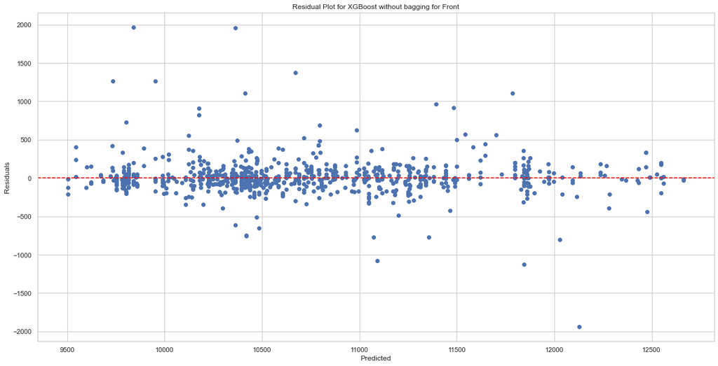

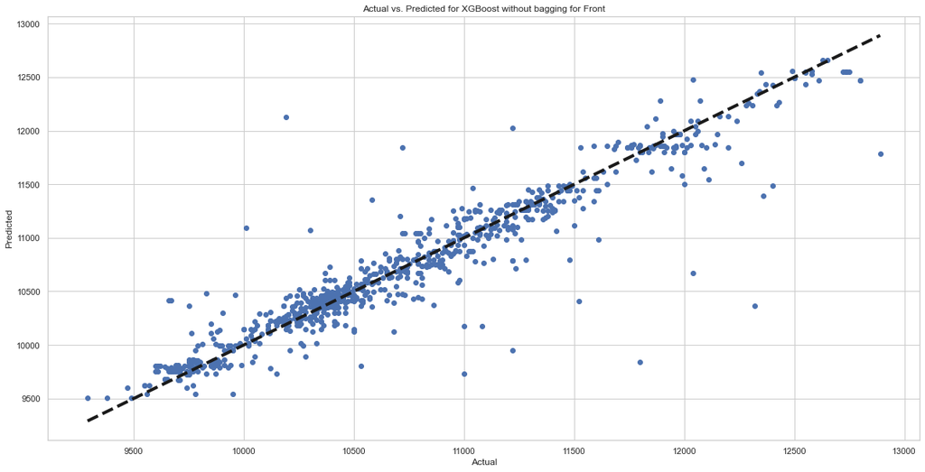

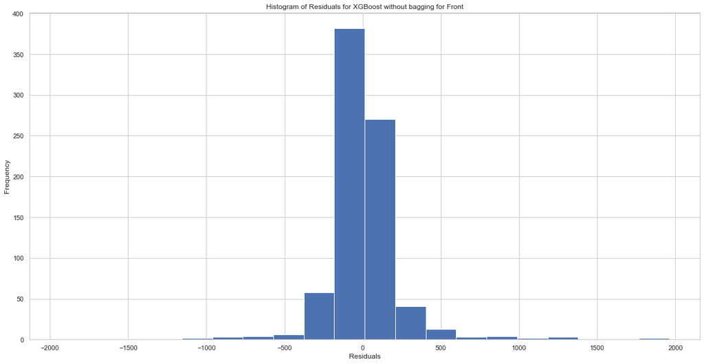

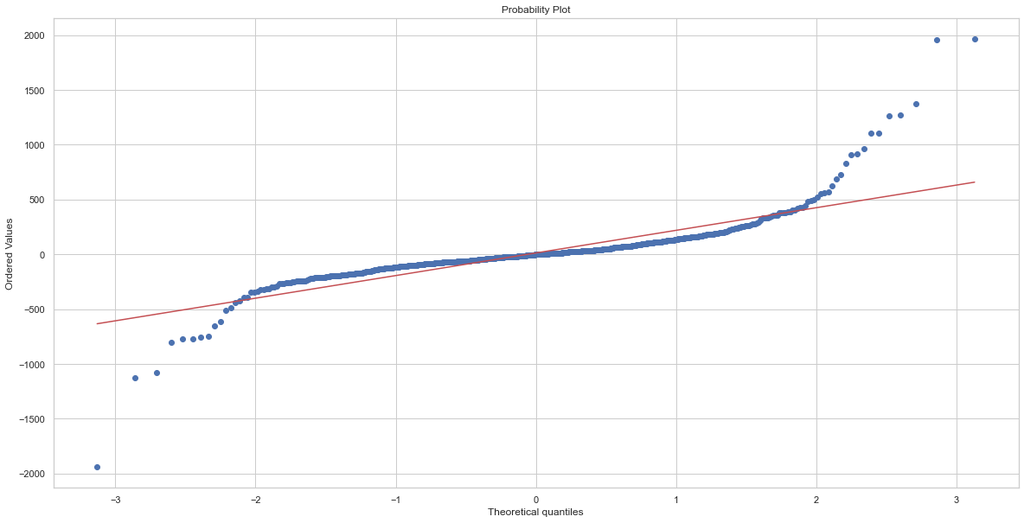

```python
def plotReliabilityGraphs(y_test,y_pred,plot_name):
    residuals = y_test - y_pred
    plt.scatter(y_pred, residuals)
    plt.axhline(0, color='red', linestyle='--')
    plt.xlabel('Predicted')
    plt.ylabel('Residuals')
    plt.title(f'Residual Plot for {plot_name}')
    plt.show()

    plt.scatter(y_test, y_pred)
    plt.plot([y_test.min(), y_test.max()], [y_test.min(), y_test.max()], 'k--', lw=4)
    plt.xlabel('Actual')
    plt.ylabel('Predicted')
    plt.title(f'Actual vs. Predicted for {plot_name}')
    plt.show()

    plt.hist(residuals, bins=20)
    plt.xlabel('Residuals')
    plt.ylabel('Frequency')
    plt.title(f'Histogram of Residuals for {plot_name}')
    plt.show()

    stats.probplot(residuals, plot=plt)
    plt.show()

plotReliabilityGraphs(y_test,y_pred,'XGBoost without bagging for Front')
```

```
MAE:  132.40994224260075
```

[figure not shown]

[figure not shown]

[figure not shown]

[figure not shown]

```python
xgb_model = XGBRegressor(n_estimators=495, learning_rate=0.133354970082411, max_depth=7, reg_lambda=4.53385562551496e-08, subsample=0.8141582328181602, colsample_bytree=0.7732232759096854, gamma=0.34364076800046645, min_child_weight=1, random_state=42)

# Wrapping the model within a BaggingRegressor
bagging_model_front = BaggingRegressor(base_estimator=xgb_model, n_estimators=3, random_state=0)
bagging_model_front.fit(X_train, y_train)
y_pred = bagging_model_front.predict(X_test)
print("MAE: ", mean_absolute_error(y_test, y_pred))

plotReliabilityGraphs(y_test,y_pred, 'XGBoost with Bagging Regressor for Front')
```

### Building the Total Model

```python
prep_fe_pipeline_total = Pipeline([
    ('drop_Targets', DropTargets()),
    ('convert_cat_to_string', convertCatColumnsToString()),
    ('replace_dot', replaceDot()),
    ('replace_space', replaceSpace()),
    ('str_to_cat', StringToCategory()),
    ('upper_lower', CheckUpperAndLowerBound()),
    ('target_encode', ce.TargetEncoder(handle_unknown='value', handle_missing='value')),
    ('scale', DataFrameScaler()),
    ('DropIdColumn', DropIDColumn(['TruckSID'])),
    ])

formattedData = prep_fe_pipeline_total.fit_transform(training,target_ActualWeightTotal)
X_train, X_test, y_train, y_test = train_test_split(formattedData, target_ActualWeightTotal, test_size=0.2, random_state=2)
X_train
```

|  | Engine | Transmission | FrontAxlePosition | WheelBase | Overhang | FrameRails | Liner | FrontEndExt | Cab | RearAxels | RearSusp | FrontSusp | RearWheels | RearTires | FrontWheels | FrontTires | TagAxle | EngineFamily | TransmissionFamily |
| --- | --- | --- | --- | --- | --- | --- | --- | --- | --- | --- | --- | --- | --- | --- | --- | --- | --- | --- | --- |
| 2334 | -0.145792 | 1.184255 | 0.085077 | 0.158427 | -1.768214 | 0.636769 | -0.890816 | -0.061616 | -1.345265 | -1.989421 | -3.572198 | 0.690944 | -0.667824 | 0.521415 | -1.016930 | 0.194185 | -0.117407 | -0.072367 | 1.059240 |
| 1165 | 2.446572 | 1.184255 | 0.085077 | -0.030941 | -0.261961 | -1.325093 | 1.128937 | -0.061616 | -0.536155 | 0.308506 | 0.269660 | -1.450352 | 0.357058 | 0.521415 | 0.452175 | 0.538199 | -0.117407 | 2.464098 | 1.059240 |
| 510 | -0.680991 | 1.184255 | 0.085077 | 2.620206 | 0.867729 | 0.636769 | 1.128937 | -0.061616 | -1.345265 | 0.596275 | 0.269660 | 0.690944 | 0.326938 | 0.521415 | 0.985025 | 0.194185 | -0.117407 | -0.685647 | 1.059240 |
| 1114 | 1.928706 | 1.184255 | 0.085077 | -0.788411 | 0.491165 | -1.325093 | 1.128937 | -0.061616 | 0.923031 | 0.308506 | 0.269660 | 0.690944 | 0.357058 | 0.521415 | 0.195839 | 0.194185 | -0.117407 | 1.886329 | 1.059240 |
| 1436 | -0.680991 | -0.776702 | 0.085077 | 0.915898 | 0.867729 | 0.636769 | 1.128937 | -0.061616 | 0.923031 | 0.308506 | 0.269660 | 0.690944 | 0.357058 | 0.521415 | 0.195839 | 0.194185 | -0.117407 | -0.685647 | -0.944073 |
| ... | ... | ... | ... | ... | ... | ... | ... | ... | ... | ... | ... | ... | ... | ... | ... | ... | ... | ... | ... |
| 2514 | -0.145792 | 1.184255 | 0.085077 | 0.537162 | 0.867729 | 0.636769 | 1.128937 | -0.061616 | -1.345265 | 0.596275 | 0.269660 | 0.690944 | 0.326938 | -0.675918 | 0.985025 | 0.194185 | -0.117407 | -0.072367 | 1.059240 |
| 2347 | -0.145792 | 1.184255 | 0.085077 | 0.537162 | -1.391651 | 0.636769 | 1.128937 | -0.061616 | -1.345265 | 0.596275 | 0.269660 | 0.690944 | 0.326938 | -0.675918 | -1.016930 | 0.194185 | -0.117407 | -0.072367 | 1.059240 |
| 1608 | -0.680991 | -0.776702 | 0.085077 | -0.788411 | 0.867729 | 0.636769 | -0.890816 | -0.061616 | -1.345265 | -1.989421 | -3.572198 | -1.450352 | -0.967372 | 0.521415 | -1.016930 | 0.194185 | -0.117407 | -0.685647 | -0.944073 |
| 2541 | -0.680991 | -0.776702 | 0.085077 | -0.030941 | -0.261961 | -1.325093 | 1.128937 | -0.061616 | 0.923031 | 0.596275 | 0.269660 | 0.690944 | -2.236636 | -3.161144 | -2.556963 | -3.647514 | -0.117407 | -0.685647 | -0.944073 |
| 2575 | -0.680991 | -0.776702 | 0.085077 | 0.158427 | 0.867729 | 0.636769 | -0.890816 | -0.061616 | 0.923031 | -1.989421 | 0.269660 | 0.690944 | 0.326938 | 0.521415 | 0.985025 | 0.194185 | -0.117407 | -0.685647 | -0.944073 |

2115 rows × 19 columns

```
MAE: 276.7864632561437
```

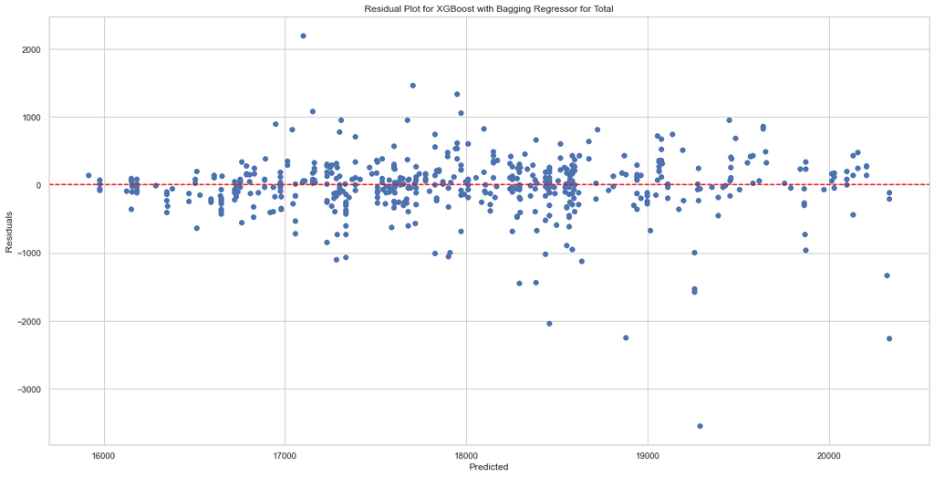

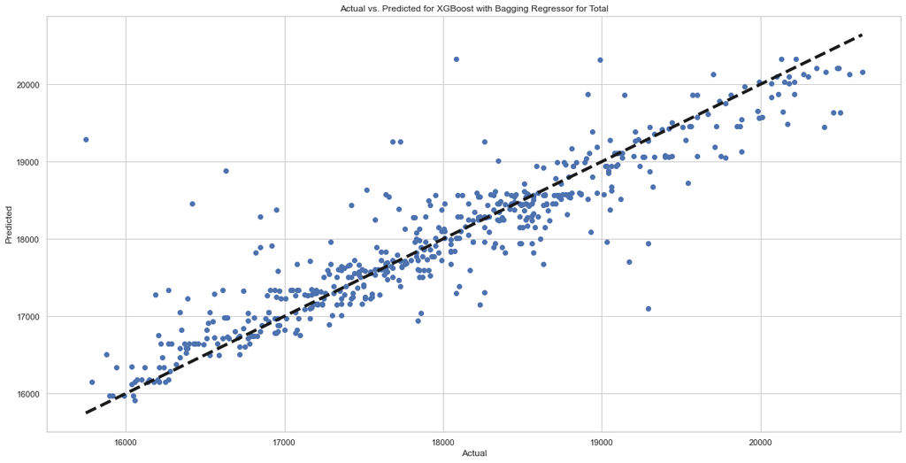

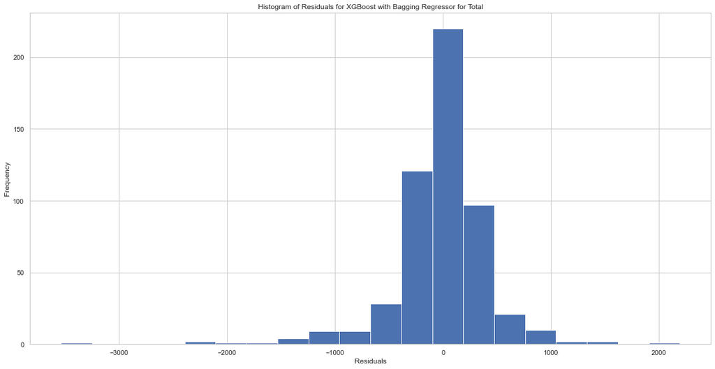

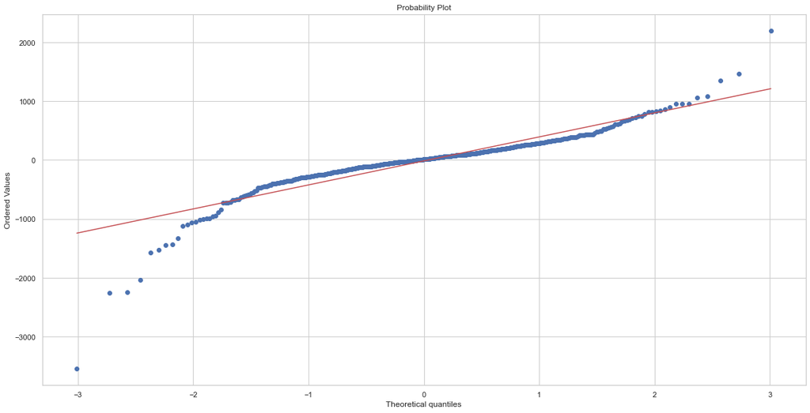

```python
#{'n_estimators': 993, 'learning_rate': 0.24702617076976288, 'max_depth': 8, 'reg_lambda': 1.3184725672621053e-09, 'subsample': 0.7745537544177631, 'colsample_bytree': 0.5084493201928549, 'gamma': 0.9975234538045155, 'min_child_weight': 9}
xgb_model = XGBRegressor(n_estimators=993, learning_rate=0.24702617076976288, max_depth=8, reg_lambda=1.3184725672621053e-09, subsample=0.7745537544177631, colsample_bytree=0.5084493201928549, gamma=0.9975234538045155, min_child_weight=9,random_state=42)

# Wrapping the model within a BaggingRegressor
bagging_model_total = BaggingRegressor(base_estimator=xgb_model, n_estimators=10)
bagging_model_total.fit(X_train, y_train)
y_pred = bagging_model_total.predict(X_test)
print('MAE:', mean_absolute_error(y_test, y_pred))

plotReliabilityGraphs(y_test,y_pred, 'XGBoost with Bagging Regressor for Total')
```

### 📝 Predicting The Test Data

```python
testData = pd.read_csv('testing.csv',delimiter=';')
test_data_for_total = prep_fe_pipeline_total.transform(testData)
test_data_for_front = prep_fe_pipeline_front.transform(testData)
```

```python
total_pred = bagging_model_total.predict(test_data_for_total).astype(int)
front_pred = bagging_model_front.predict(test_data_for_front).astype(int)
back_pred = (total_pred - front_pred).astype(int)
```

```python
finalDf = pd.DataFrame({'TruckSID':testData['TruckSID'],
                        'PredictedWeightFront':front_pred.flatten(),
                        'PredictedWeightBack':back_pred.flatten(),
                        'PredictedWeightTotal':total_pred.flatten()})

finalDf.to_csv('finalProduct2.csv', index=False)
```

```python
pred = bagging_model_front.predict(test_data_for_front)
```

```python
pred
```

[output not shown]

[output cut: 138 more lines]

```
       10479.762 ,  9831.267 , 10348.397 , 10659.266 , 10871.276 ,
       11238.733 ,  9777.745 , 10668.087 ,  9990.332 , 10479.762 ,
        9831.267 , 10348.397 , 10659.266 , 10871.276 , 11238.733 ,
        9777.745 , 10668.087 ,  9990.332 , 10479.762 ,  9831.267 ,
       10348.397 , 10659.266 , 10871.276 , 11238.733 , 11991.761 ,
        9777.745 , 10668.087 ,  9990.332 , 10479.762 ,  9831.267 ,
       10348.397 , 10659.266 , 10871.276 , 11238.733 , 11991.761 ,
        9777.745 , 10668.087 ,  9990.332 , 10479.762 ,  9831.267 ,
       10348.397 , 10659.266 , 10871.276 , 11238.733 , 11991.761 ,
        9777.745 , 10668.087 ,  9990.332 , 10479.762 ,  9831.267 ,
       10348.397 , 10659.266 , 10871.276 , 11238.733 , 11991.761 ,
        9777.745 , 10668.087 ,  9990.332 , 10479.762 ,  9831.267 ,
       10348.397 , 11287.884 , 10659.266 , 10871.276 , 11238.733 ,
       11991.761 ,  9777.745 , 10668.087 ,  9990.332 , 10479.762 ,
        9831.267 , 10348.397 ], dtype=float32)
```